# Final_Reasonableness_Medians

This is the formal analysis file for the “The Nature of Reasonableness” by by Kevin Tobia, Ivar R. Hannikainen, David Kamper, Guilherme Almeida, Piotr Bystranowski, Niek Strohmaier, Vilius Dranseika, Markus Kneer, Fernando Aguiar, Kristina Dolinina, Bartosz Janik, Eglė Lauraitytė, Alice Liefgreen, Maciej Próchnicki, Alejandro Rosas, Vivek Kumar Shukla, and Noel Struchiner (2025, Stanford Journal of International Law).

## Introduction and Loading of Files

```r
# Load Libraries

library(dplyr)
library(tidyverse)
```

```r
library(stats)
library(ggplot2)
library(ggthemes)
library(corrplot)
library(gridExtra)
library(kableExtra)
library(effects)
library(scales)
DATA_PATH <- "/Users/dgkamper/Library/CloudStorage/GoogleDrive-dgkamper@gmail.com/My Drive/DGK Lab/Collaborations/Language and Law Laboratory/Analysis/LegalResonablenessAnalysis/Data_all_numeric.csv"
```

#### 1. Initial Data Loading and Preparation

```r
# Read the data from specified path
Data_All <- read.csv(DATA_PATH, stringsAsFactors = FALSE)

# Verify data structure
glimpse(Data_All)
```

```
## Rows: 2,426
## Columns: 42
## $ q1             <dbl> 2, 2, 2, 2, 2, 2, 2, 2, 2, 2, 2, 2, 2, 2, 2, 2, 2, 2, 2…
## $ q2             <dbl> 0, 0, 0, 0, 0, 0, 0, 0, 0, 0, 0, 0, 0, 0, 0, 0, 0, 0, 0…
## $ q3             <dbl> 8, 8, 8, 8, 8, 8, 8, 8, 8, 8, 8, 8, 8, 8, 8, 8, 8, 8, 8…
## $ q4             <dbl> 2500, 2500, 2500, 2500, 2500, 2500, 2500, 2500, 2500, 2…
## $ q5             <dbl> 120, 120, 120, 120, 120, 120, 120, 120, 120, 120, 120, …
## $ q6             <dbl> 0, 0, 0, 0, 0, 0, 0, 0, 0, 0, 0, 0, 0, 0, 0, 0, 0, 0, 0…
## $ q7             <dbl> 20, 20, 20, 20, 20, 20, 20, 20, 20, 20, 20, 20, 20, 20,…
## $ q8             <dbl> 100, 100, 100, 100, 100, 100, 100, 100, 100, 100, 100, …
## $ q9             <dbl> 0, 0, 0, 0, 0, 0, 0, 0, 0, 0, 0, 0, 0, 0, 0, 0, 0, 0, 0…
## $ q10            <dbl> 3, 3, 3, 3, 3, 3, 3, 3, 3, 3, 3, 3, 3, 3, 3, 3, 3, 3, 3…
## $ q11            <dbl> 0, 0, 0, 0, 0, 0, 0, 0, 0, 0, 0, 0, 0, 0, 0, 0, 0, 0, 0…
## $ q12            <dbl> 0, 0, 0, 0, 0, 0, 0, 0, 0, 0, 0, 0, 0, 0, 0, 0, 0, 0, 0…
## $ q13            <dbl> 25, 25, 25, 25, 25, 25, 25, 25, 25, 25, 25, 25, 25, 25,…
```

[output cut: 29 more lines]

#### 2. Exclude participants whose answer to Q19 does not equal 15 [comprehension/attention question].

```r
# Split data by condition
Data_All_Average <- Data_All %>% filter(Condition_name == "Average")
Data_All_Ideal <- Data_All %>% filter(Condition_name == "Ideal")
Data_All_Reasonable <- Data_All %>% filter(Condition_name == "Reasonable")

# Exclude participants whose answer to Q19 does not equal 15 [comprehension/attention question].
Data_All_Average_Pass1 <- Data_All_Average %>% filter(q19 == 15)
Data_All_Ideal_Pass1 <- Data_All_Ideal %>% filter(q19 == 15)
Data_All_Reasonable_Pass1 <- Data_All_Reasonable %>% filter(q19 == 15)

# Print participant counts
condition_counts <- data.frame(
  Condition = c("Average", "Ideal", "Reasonable"),
  Original_Count = c(nrow(Data_All_Average), nrow(Data_All_Ideal), nrow(Data_All_Reasonable)),
  After_Attention_Check = c(nrow(Data_All_Average_Pass1), nrow(Data_All_Ideal_Pass1), nrow(Data_All_Reasonable_Pass1)),
  Excluded_Count = c(nrow(Data_All_Average) - nrow(Data_All_Average_Pass1),
                     nrow(Data_All_Ideal) - nrow(Data_All_Ideal_Pass1),
                     nrow(Data_All_Reasonable) - nrow(Data_All_Reasonable_Pass1)),
  Exclusion_Rate = c((nrow(Data_All_Average) - nrow(Data_All_Average_Pass1))/nrow(Data_All_Average),
                     (nrow(Data_All_Ideal) - nrow(Data_All_Ideal_Pass1))/nrow(Data_All_Ideal),
                     (nrow(Data_All_Reasonable) - nrow(Data_All_Reasonable_Pass1))/nrow(Data_All_Reasonable))
)

# Format the exclusion rate as percentage
condition_counts$Exclusion_Rate <- scales::percent(condition_counts$Exclusion_Rate)

# Display the participant counts table
kable(condition_counts, caption = "Participant Counts Before and After Attention Check") %>%
  kable_styling(bootstrap_options = c("striped", "hover", "condensed"), full_width = F)
```

Participant Counts Before and After Attention Check

| Condition | Original_Count | After_Attention_Check | Excluded_Count | Exclusion_Rate |
| --- | --- | --- | --- | --- |
| Average | 815 | 793 | 22 | 2.70% |
| Ideal | 825 | 800 | 25 | 3.03% |
| Reasonable | 786 | 758 | 28 | 3.56% |

```r
# Define the question columns - ensuring they actually exist in the data
question_cols <- c("q1", "q2", "q3", "q4", "q5", "q6", "q7", "q8", "q9", "q10",
                  "q11", "q12", "q13", "q14", "q15", "q16", "q17", "q18",
                  "q20", "q21", "q22", "q23", "q24", "q25", "q26", "q27",
                  "q28", "q29", "q30", "q31", "q32", "q33", "q34")

# Check if all question columns exist in the data
existing_cols <- question_cols[question_cols %in% colnames(Data_All_Average_Pass1)]
missing_cols <- question_cols[!question_cols %in% colnames(Data_All_Average_Pass1)]

print("Existing question columns:")
```

```
## [1] "Existing question columns:"
```

```r
print(existing_cols)
```

```
##  [1] "q1"  "q2"  "q3"  "q4"  "q5"  "q6"  "q7"  "q8"  "q9"  "q10" "q11" "q12"
## [13] "q13" "q14" "q15" "q16" "q17" "q18" "q20" "q21" "q22" "q23" "q24" "q25"
## [25] "q26" "q27" "q28" "q29" "q30" "q31" "q32" "q33" "q34"
```

```r
print("Missing question columns:")
```

```
## [1] "Missing question columns:"
```

```r
print(missing_cols)
```

```
## character(0)
```

#### 3. Check Number of Participants per Condition

```r
# Continue with only the existing columns
question_cols <- existing_cols

# Convert columns to numeric
Data_All_Average_Pass1 <- Data_All_Average_Pass1 %>%
  mutate(across(all_of(question_cols), ~as.numeric(as.character(.))))

Data_All_Ideal_Pass1 <- Data_All_Ideal_Pass1 %>%
  mutate(across(all_of(question_cols), ~as.numeric(as.character(.))))
Data_All_Reasonable_Pass1 <- Data_All_Reasonable_Pass1 %>%
  mutate(across(all_of(question_cols), ~as.numeric(as.character(.))))

# Verify the number of participants in each condition
cat("Ideal condition:", nrow(Data_All_Ideal_Pass1), "participants\n")
```

```
## Ideal condition: 800 participants
```

```r
cat("Average condition:", nrow(Data_All_Average_Pass1), "participants\n")
```

```
## Average condition: 793 participants
```

```r
cat("Reasonable condition:", nrow(Data_All_Reasonable_Pass1), "participants\n")
```

```
## Reasonable condition: 758 participants
```

#### 4a. Filter Data [Due to medians, exclusions of outliers]

No parts to be completed here: done in Analysis 3.

#### 4b. Filter Data [Any response that is > 3SD from QMean, exclude]

```r
# Function to filter data based on 3 SD criterion
filter_data <- function(data, cols) {
  # Pre-allocate a list to track excluded participants for each question
  exclusions_by_question <- list()

  # Original count
  original_count <- nrow(data)

  result <- data
  for (col in cols) {
    if (col %in% colnames(data)) {
      # Calculate mean and standard deviation
      avg <- mean(result[[col]], na.rm = TRUE)
      s <- sd(result[[col]], na.rm = TRUE)

      # Identify outliers
      outlier_indices <- which(!is.na(result[[col]]) & abs(result[[col]] - avg) > 3 * s)
      exclusions_by_question[[col]] <- length(outlier_indices)

      # Filter out outliers
      result <- result %>%
        filter(is.na(!!sym(col)) | abs(!!sym(col) - avg) <= 3 * s)
    }
  }

  # Final count
  final_count <- nrow(result)

  return(list(
    filtered_data = result,
    original_count = original_count,
    final_count = final_count,
    excluded_count = original_count - final_count,
    exclusion_rate = (original_count - final_count) / original_count,
    exclusions_by_question = exclusions_by_question
  ))
}

# Apply filtering and track exclusion counts
avg_filter_results <- filter_data(Data_All_Average_Pass1, question_cols)
ideal_filter_results <- filter_data(Data_All_Ideal_Pass1, question_cols)
reasonable_filter_results <- filter_data(Data_All_Reasonable_Pass1, question_cols)

# Extract the filtered data
Data_All_Average_Filtered <- avg_filter_results$filtered_data
Data_All_Ideal_Filtered <- ideal_filter_results$filtered_data
Data_All_Reasonable_Filtered <- reasonable_filter_results$filtered_data

# Display outlier exclusion summary
outlier_summary <- data.frame(
  Condition = c("Average", "Ideal", "Reasonable"),
  Original_Count = c(avg_filter_results$original_count,
                    ideal_filter_results$original_count,
                    reasonable_filter_results$original_count),
  After_Outlier_Removal = c(avg_filter_results$final_count,
                           ideal_filter_results$final_count,
                           reasonable_filter_results$final_count),
  Excluded_Count = c(avg_filter_results$excluded_count,
                    ideal_filter_results$excluded_count,
                    reasonable_filter_results$excluded_count),
  Exclusion_Rate = c(avg_filter_results$exclusion_rate,
                    ideal_filter_results$exclusion_rate,
                    reasonable_filter_results$exclusion_rate)
)

# Format the exclusion rate as percentage
outlier_summary$Exclusion_Rate <- scales::percent(outlier_summary$Exclusion_Rate)

# Display the outlier exclusion summary table
kable(outlier_summary, caption = "Participant Counts Before and After Outlier Removal") %>%
  kable_styling(bootstrap_options = c("striped", "hover", "condensed"), full_width = F)
```

Participant Counts Before and After Outlier Removal

| Condition | Original_Count | After_Outlier_Removal | Excluded_Count | Exclusion_Rate |
| --- | --- | --- | --- | --- |
| Average | 793 | 609 | 184 | 23.20% |
| Ideal | 800 | 608 | 192 | 24.00% |
| Reasonable | 758 | 720 | 38 | 5.01% |

```r
# Define helper function for coefficients
get_model_coefs <- function(model) {
  summary_model <- summary(model)
  coef_table <- summary_model$coefficients
  data.frame(
    Term = rownames(coef_table),
    Estimate = coef_table[, "Estimate"],
    Std_Error = coef_table[, "Std. Error"],
    t_value = coef_table[, "t value"],
    p_value = coef_table[, "Pr(>|t|)"]
  )
}

# Define helper function for p-values
format_pvalue <- function(p) {
  ifelse(p < 0.001, "< .001", round(p, 3))
}
```

# Analysis 3 [NO 3 SD Removed]: Overall results, with median ratings

#### 1. Compute the median rating

```r
# Calculate medians from attention-check filtered data ONLY
column_medians_average_no3sd <- sapply(Data_All_Average_Pass1[, question_cols], median, na.rm = TRUE)
column_medians_ideal_no3sd <- sapply(Data_All_Ideal_Pass1[, question_cols], median, na.rm = TRUE)
column_medians_reasonable_no3sd <- sapply(Data_All_Reasonable_Pass1[, question_cols], median, na.rm = TRUE)

# Create a dataframe for the medians
medians_df_no3sd <- data.frame(
  Question = names(column_medians_average_no3sd),
  Average = column_medians_average_no3sd,
  Ideal = column_medians_ideal_no3sd,
  Reasonable = column_medians_reasonable_no3sd
)

# Display the medians for each question
kable(medians_df_no3sd, caption = "Median Values (NO 3SD Removal)") %>%
  kable_styling(bootstrap_options = c("striped", "hover", "condensed"), full_width = F)
```

Median Values (NO 3SD Removal)

|  | Question | Average | Ideal | Reasonable |
| --- | --- | --- | --- | --- |
| q1 | q1 | 3.0 | 2.0 | 2 |
| q2 | q2 | 7.0 | 2.0 | 0 |
| q3 | q3 | 3.0 | 6.0 | 8 |
| q4 | q4 | 2000.0 | 2000.0 | 2500 |
| q5 | q5 | 20.0 | 30.0 | 120 |
| q6 | q6 | 10.0 | 1.0 | 0 |
| q7 | q7 | 15.0 | 5.0 | 20 |
| q8 | q8 | 5.0 | 12.0 | 100 |
| q9 | q9 | 5.0 | 3.0 | 0 |
| q10 | q10 | 5.0 | 0.0 | 3 |
| q11 | q11 | 500.0 | 0.0 | 0 |
| q12 | q12 | 30.0 | 1.0 | 0 |
| q13 | q13 | 40.0 | 10.0 | 25 |
| q14 | q14 | 10.0 | 2.0 | 30 |
| q15 | q15 | 9.0 | 10.0 | 25 |
| q16 | q16 | 5.0 | 5.0 | 5 |
| q17 | q17 | 3.0 | 0.0 | 3 |
| q18 | q18 | 15.0 | 2.0 | 12 |
| q20 | q20 | 20.0 | 0.0 | 0 |
| q21 | q21 | 8.0 | 5.0 | 0 |
| q22 | q22 | 10.0 | 7.0 | 1 |
| q23 | q23 | 2.0 | 3.0 | 1 |
| q24 | q24 | 16.0 | 24.0 | 5 |
| q25 | q25 | 2000.0 | 500.0 | 0 |
| q26 | q26 | 8.0 | 2.0 | 3 |
| q27 | q27 | 12.0 | 5.0 | 0 |
| q28 | q28 | 10.0 | 20.0 | 20 |
| q29 | q29 | 55.0 | 90.0 | 80 |
| q30 | q30 | 12.0 | 4.0 | 4 |
| q31 | q31 | 50.0 | 13.0 | 25 |
| q32 | q32 | 24.0 | 48.0 | 40 |
| q33 | q33 | 5.5 | 2.5 | 4 |
| q34 | q34 | 50.0 | 10.0 | 50 |

#### 2a. (Small constant inf values): Convert median responses to a natural log scale (NO 3SD Removal)

```r
# Log function: Small constant for zero
log_smallvalue <- function(x) {
  x_safe <- x
  # Replace only actual zeros, leave NAs as NA
  x_safe[which(x == 0 & !is.na(x))] <- 0.01
  log(x_safe)
}

# Apply the log function
log_medians_average_no3sd_smallval <- log_smallvalue(column_medians_average_no3sd)
log_medians_ideal_no3sd_smallval <- log_smallvalue(column_medians_ideal_no3sd)
log_medians_reasonable_no3sd_smallval <- log_smallvalue(column_medians_reasonable_no3sd)

# Create a dataframe for the log medians
log_medians_df_no3sd_smallval <- data.frame(
  Question = names(log_medians_average_no3sd_smallval),
  Average = log_medians_average_no3sd_smallval,
  Ideal = log_medians_ideal_no3sd_smallval,
  Reasonable = log_medians_reasonable_no3sd_smallval
)

# Display the log medians
kable(log_medians_df_no3sd_smallval, caption = "Log-Transformed (Small Constant) Median Values (NO 3SD Removal)") %>%
  kable_styling(bootstrap_options = c("striped", "hover", "condensed"), full_width = F)
```

Log-Transformed (Small Constant) Median Values (NO 3SD Removal)

|  | Question | Average | Ideal | Reasonable |
| --- | --- | --- | --- | --- |
| q1 | q1 | 1.0986123 | 0.6931472 | 0.6931472 |
| q2 | q2 | 1.9459101 | 0.6931472 | -4.6051702 |
| q3 | q3 | 1.0986123 | 1.7917595 | 2.0794415 |
| q4 | q4 | 7.6009025 | 7.6009025 | 7.8240460 |
| q5 | q5 | 2.9957323 | 3.4011974 | 4.7874917 |
| q6 | q6 | 2.3025851 | 0.0000000 | -4.6051702 |
| q7 | q7 | 2.7080502 | 1.6094379 | 2.9957323 |
| q8 | q8 | 1.6094379 | 2.4849066 | 4.6051702 |
| q9 | q9 | 1.6094379 | 1.0986123 | -4.6051702 |
| q10 | q10 | 1.6094379 | -4.6051702 | 1.0986123 |
| q11 | q11 | 6.2146081 | -4.6051702 | -4.6051702 |
| q12 | q12 | 3.4011974 | 0.0000000 | -4.6051702 |
| q13 | q13 | 3.6888795 | 2.3025851 | 3.2188758 |
| q14 | q14 | 2.3025851 | 0.6931472 | 3.4011974 |
| q15 | q15 | 2.1972246 | 2.3025851 | 3.2188758 |
| q16 | q16 | 1.6094379 | 1.6094379 | 1.6094379 |
| q17 | q17 | 1.0986123 | -4.6051702 | 1.0986123 |
| q18 | q18 | 2.7080502 | 0.6931472 | 2.4849066 |
| q20 | q20 | 2.9957323 | -4.6051702 | -4.6051702 |
| q21 | q21 | 2.0794415 | 1.6094379 | -4.6051702 |
| q22 | q22 | 2.3025851 | 1.9459101 | 0.0000000 |
| q23 | q23 | 0.6931472 | 1.0986123 | 0.0000000 |
| q24 | q24 | 2.7725887 | 3.1780538 | 1.6094379 |
| q25 | q25 | 7.6009025 | 6.2146081 | -4.6051702 |
| q26 | q26 | 2.0794415 | 0.6931472 | 1.0986123 |
| q27 | q27 | 2.4849066 | 1.6094379 | -4.6051702 |
| q28 | q28 | 2.3025851 | 2.9957323 | 2.9957323 |
| q29 | q29 | 4.0073332 | 4.4998097 | 4.3820266 |
| q30 | q30 | 2.4849066 | 1.3862944 | 1.3862944 |
| q31 | q31 | 3.9120230 | 2.5649494 | 3.2188758 |
| q32 | q32 | 3.1780538 | 3.8712010 | 3.6888795 |
| q33 | q33 | 1.7047481 | 0.9162907 | 1.3862944 |
| q34 | q34 | 3.9120230 | 2.3025851 | 3.9120230 |

#### 2b. (Plus one to all values): Convert median responses to a natural log scale (NO 3SD Removal)

```r
# Log function: Add 1
log_plus_one <- function(x) {
  log(x + 1)
}

# Apply the log function
log_medians_average_no3sd_plusone <- log_plus_one(column_medians_average_no3sd)
log_medians_ideal_no3sd_plusone <- log_plus_one(column_medians_ideal_no3sd)
log_medians_reasonable_no3sd_plusone <- log_plus_one(column_medians_reasonable_no3sd)

# Create a dataframe for the log medians
log_medians_df_no3sd_plusone <- data.frame(
  Question = names(log_medians_average_no3sd_plusone),
  Average = log_medians_average_no3sd_plusone,
  Ideal = log_medians_ideal_no3sd_plusone,
  Reasonable = log_medians_reasonable_no3sd_plusone
)

# Display the log medians
kable(log_medians_df_no3sd_plusone, caption = "Log-Transformed (Plus One) Median Values (NO 3SD Removal)") %>%
  kable_styling(bootstrap_options = c("striped", "hover", "condensed"), full_width = F)
```

Log-Transformed (Plus One) Median Values (NO 3SD Removal)

|  | Question | Average | Ideal | Reasonable |
| --- | --- | --- | --- | --- |
| q1 | q1 | 1.386294 | 1.0986123 | 1.0986123 |
| q2 | q2 | 2.079442 | 1.0986123 | 0.0000000 |
| q3 | q3 | 1.386294 | 1.9459101 | 2.1972246 |
| q4 | q4 | 7.601402 | 7.6014023 | 7.8244459 |
| q5 | q5 | 3.044522 | 3.4339872 | 4.7957905 |
| q6 | q6 | 2.397895 | 0.6931472 | 0.0000000 |
| q7 | q7 | 2.772589 | 1.7917595 | 3.0445224 |
| q8 | q8 | 1.791759 | 2.5649494 | 4.6151205 |
| q9 | q9 | 1.791759 | 1.3862944 | 0.0000000 |
| q10 | q10 | 1.791759 | 0.0000000 | 1.3862944 |
| q11 | q11 | 6.216606 | 0.0000000 | 0.0000000 |
| q12 | q12 | 3.433987 | 0.6931472 | 0.0000000 |
| q13 | q13 | 3.713572 | 2.3978953 | 3.2580965 |
| q14 | q14 | 2.397895 | 1.0986123 | 3.4339872 |
| q15 | q15 | 2.302585 | 2.3978953 | 3.2580965 |
| q16 | q16 | 1.791759 | 1.7917595 | 1.7917595 |
| q17 | q17 | 1.386294 | 0.0000000 | 1.3862944 |
| q18 | q18 | 2.772589 | 1.0986123 | 2.5649494 |
| q20 | q20 | 3.044522 | 0.0000000 | 0.0000000 |
| q21 | q21 | 2.197225 | 1.7917595 | 0.0000000 |
| q22 | q22 | 2.397895 | 2.0794415 | 0.6931472 |
| q23 | q23 | 1.098612 | 1.3862944 | 0.6931472 |
| q24 | q24 | 2.833213 | 3.2188758 | 1.7917595 |
| q25 | q25 | 7.601402 | 6.2166061 | 0.0000000 |
| q26 | q26 | 2.197225 | 1.0986123 | 1.3862944 |
| q27 | q27 | 2.564949 | 1.7917595 | 0.0000000 |
| q28 | q28 | 2.397895 | 3.0445224 | 3.0445224 |
| q29 | q29 | 4.025352 | 4.5108595 | 4.3944492 |
| q30 | q30 | 2.564949 | 1.6094379 | 1.6094379 |
| q31 | q31 | 3.931826 | 2.6390573 | 3.2580965 |
| q32 | q32 | 3.218876 | 3.8918203 | 3.7135721 |
| q33 | q33 | 1.871802 | 1.2527630 | 1.6094379 |
| q34 | q34 | 3.931826 | 2.3978953 | 3.9318256 |

#### 3a. (Small constant inf values): Conduct three regressions and record AIC (NO 3SD Removal)

```r
# Create data frame for regression
dataforAICMedians_no3sd_smallval <- data.frame(
  Reasonable = log_medians_reasonable_no3sd_smallval,
  Average = log_medians_average_no3sd_smallval,
  Ideal = log_medians_ideal_no3sd_smallval
)

# Filter out rows with non-finite values before regression
dataforAICMedians_no3sd_smallval <- dataforAICMedians_no3sd_smallval %>% filter(is.finite(Reasonable) & is.finite(Average) & is.finite(Ideal))

# Model I: Median Average predicts Median Reasonable
Model1Medians_no3sd_smallval <- lm(Reasonable ~ Average, data = dataforAICMedians_no3sd_smallval)
AIC1Medians_no3sd_smallval <- AIC(Model1Medians_no3sd_smallval)
r2_model1_median_no3sd_smallval <- summary(Model1Medians_no3sd_smallval)$r.squared

# Model II: Median Ideal predicts Median Reasonable
Model2Medians_no3sd_smallval <- lm(Reasonable ~ Ideal, data = dataforAICMedians_no3sd_smallval)
AIC2Medians_no3sd_smallval <- AIC(Model2Medians_no3sd_smallval)
r2_model2_median_no3sd_smallval <- summary(Model2Medians_no3sd_smallval)$r.squared

# Model III: Both Median Average and Median Ideal predict Median Reasonable
Model3Medians_no3sd_smallval <- lm(Reasonable ~ Average + Ideal, data = dataforAICMedians_no3sd_smallval)
AIC3Medians_no3sd_smallval <- AIC(Model3Medians_no3sd_smallval)
r2_model3_median_no3sd_smallval <- summary(Model3Medians_no3sd_smallval)$r.squared

# Create a regression summary dataframe
regression_summary_medians_no3sd_smallval <- data.frame(
  Model = c("Average predicts Reasonable",
            "Ideal predicts Reasonable",
            "Average + Ideal predict Reasonable"),
  AIC = c(AIC1Medians_no3sd_smallval, AIC2Medians_no3sd_smallval, AIC3Medians_no3sd_smallval),
  R_squared = c(r2_model1_median_no3sd_smallval, r2_model2_median_no3sd_smallval, r2_model3_median_no3sd_smallval)
)

# Display the regression summary table
kable(regression_summary_medians_no3sd_smallval, caption = "Regression Comparison (Median, NO 3SD, Log Small Constant)") %>%
  kable_styling(bootstrap_options = c("striped", "hover", "condensed"), full_width = F)
```

Regression Comparison (Median, NO 3SD, Log Small Constant)

| Model | AIC | R_squared |
| --- | --- | --- |
| Average predicts Reasonable | 183.1287 | 0.0014857 |
| Ideal predicts Reasonable | 176.1116 | 0.1927536 |
| Average + Ideal predict Reasonable | 177.2436 | 0.2137099 |

#### 3b. (Plus one to all values): Conduct three regressions and record AIC (NO 3SD Removal)

```r
# Create data frame for regression
dataforAICMedians_no3sd_plusone <- data.frame(
  Reasonable = log_medians_reasonable_no3sd_plusone,
  Average = log_medians_average_no3sd_plusone,
  Ideal = log_medians_ideal_no3sd_plusone
)
# Filter out rows with non-finite values before regression
dataforAICMedians_no3sd_plusone <- dataforAICMedians_no3sd_plusone %>% filter(is.finite(Reasonable) & is.finite(Average) & is.finite(Ideal))


# Model I: Median Average predicts Median Reasonable
Model1Medians_no3sd_plusone <- lm(Reasonable ~ Average, data = dataforAICMedians_no3sd_plusone)
AIC1Medians_no3sd_plusone <- AIC(Model1Medians_no3sd_plusone)
r2_model1_median_no3sd_plusone <- summary(Model1Medians_no3sd_plusone)$r.squared

# Model II: Median Ideal predicts Median Reasonable
Model2Medians_no3sd_plusone <- lm(Reasonable ~ Ideal, data = dataforAICMedians_no3sd_plusone)
AIC2Medians_no3sd_plusone <- AIC(Model2Medians_no3sd_plusone)
r2_model2_median_no3sd_plusone <- summary(Model2Medians_no3sd_plusone)$r.squared

# Model III: Both Median Average and Median Ideal predict Median Reasonable
Model3Medians_no3sd_plusone <- lm(Reasonable ~ Average + Ideal, data = dataforAICMedians_no3sd_plusone)
AIC3Medians_no3sd_plusone <- AIC(Model3Medians_no3sd_plusone)
r2_model3_median_no3sd_plusone <- summary(Model3Medians_no3sd_plusone)$r.squared

# Create a regression summary dataframe
regression_summary_medians_no3sd_plusone <- data.frame(
  Model = c("Average predicts Reasonable",
            "Ideal predicts Reasonable",
            "Average + Ideal predict Reasonable"),
  AIC = c(AIC1Medians_no3sd_plusone, AIC2Medians_no3sd_plusone, AIC3Medians_no3sd_plusone),
  R_squared = c(r2_model1_median_no3sd_plusone, r2_model2_median_no3sd_plusone, r2_model3_median_no3sd_plusone)
)

# Display the regression summary table
kable(regression_summary_medians_no3sd_plusone, caption = "Regression Comparison (Median, NO 3SD, Log Plus One)") %>%
  kable_styling(bootstrap_options = c("striped", "hover", "condensed"), full_width = F)
```

Regression Comparison (Median, NO 3SD, Log Plus One)

| Model | AIC | R_squared |
| --- | --- | --- |
| Average predicts Reasonable | 137.2296 | 0.0803183 |
| Ideal predicts Reasonable | 123.8880 | 0.3861577 |
| Average + Ideal predict Reasonable | 124.5704 | 0.4101833 |

#### 4a. (Small constant inf values): Plots and Reporting (NO 3SD Removal)

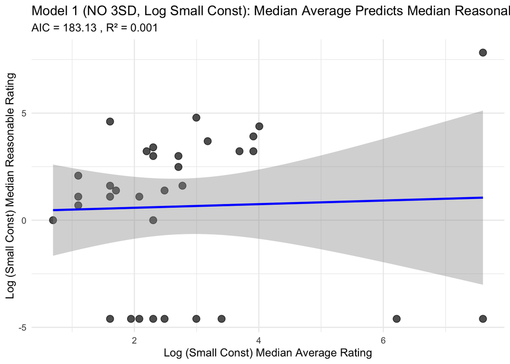

```r
# Average Median vs Reasonable Median
plot1_median_no3sd_smallval <- ggplot(dataforAICMedians_no3sd_smallval, aes(x = Average, y = Reasonable)) +
  geom_point(size = 3, alpha = 0.7) +
  geom_smooth(method = "lm", se = TRUE, color = "blue") +
  labs(title = "Model 1 (NO 3SD, Log Small Const): Median Average Predicts Median Reasonable",
       subtitle = paste("AIC =", round(AIC1Medians_no3sd_smallval, 2), ", R² =", round(r2_model1_median_no3sd_smallval, 3)),
       x = "Log (Small Const) Median Average Rating",
       y = "Log (Small Const) Median Reasonable Rating") +
  theme_minimal() # Add theme elements as before

# Ideal Median vs Reasonable Median
plot2_median_no3sd_smallval <- ggplot(dataforAICMedians_no3sd_smallval, aes(x = Ideal, y = Reasonable)) +
   geom_point(size = 3, alpha = 0.7) +
   geom_smooth(method = "lm", se = TRUE, color = "red") +
   labs(title = "Model 2 (NO 3SD, Log Small Const): Median Ideal Predicts Median Reasonable",
        subtitle = paste("AIC =", round(AIC2Medians_no3sd_smallval, 2), ", R² =", round(r2_model2_median_no3sd_smallval, 3)),
        x = "Log (Small Const) Median Ideal Rating",
        y = "Log (Small Const) Median Reasonable Rating") +
  theme_minimal() # Add theme elements

# Model 3 visualizations (effect of average, holding ideal constant)
new_data_median_no3sd_smallval <- expand.grid(
  Average = seq(min(dataforAICMedians_no3sd_smallval$Average, na.rm=TRUE), max(dataforAICMedians_no3sd_smallval$Average, na.rm=TRUE), length.out = 100),
  Ideal = median(dataforAICMedians_no3sd_smallval$Ideal, na.rm=TRUE)
)
new_data_median_no3sd_smallval <- new_data_median_no3sd_smallval[is.finite(new_data_median_no3sd_smallval$Average) & is.finite(new_data_median_no3sd_smallval$Ideal),]
if(nrow(new_data_median_no3sd_smallval)>0){
    new_data_median_no3sd_smallval$predicted_reasonable <- predict(Model3Medians_no3sd_smallval, newdata = new_data_median_no3sd_smallval)
} else {
    new_data_median_no3sd_smallval <- data.frame(Average=numeric(), Ideal=numeric(), predicted_reasonable=numeric())
}
plot3_median_no3sd_smallval <- ggplot(dataforAICMedians_no3sd_smallval, aes(x = Average, y = Reasonable)) +
  geom_point(size = 3, alpha = 0.5) +
  geom_line(data = new_data_median_no3sd_smallval, aes(y = predicted_reasonable), color = "blue", size = 1) +
  labs(title = "Model 3 (NO 3SD, Log Small Const): Effect of Median Average",
       subtitle = paste("AIC =", round(AIC3Medians_no3sd_smallval, 2), ", R² =", round(r2_model3_median_no3sd_smallval, 3)),
       x = "Log (Small Const) Median Average Rating",
       y = "Log (Small Const) Median Reasonable Rating") +
  theme_minimal() # Add theme elements
# Model 3 visualization (effect of ideal, holding average constant)
new_data2_median_no3sd_smallval <- expand.grid(
  Average = median(dataforAICMedians_no3sd_smallval$Average, na.rm=TRUE),
  Ideal = seq(min(dataforAICMedians_no3sd_smallval$Ideal, na.rm=TRUE), max(dataforAICMedians_no3sd_smallval$Ideal, na.rm=TRUE), length.out = 100)
)
new_data2_median_no3sd_smallval <- new_data2_median_no3sd_smallval[is.finite(new_data2_median_no3sd_smallval$Average) & is.finite(new_data2_median_no3sd_smallval$Ideal),]
if(nrow(new_data2_median_no3sd_smallval)>0){
    new_data2_median_no3sd_smallval$predicted_reasonable <- predict(Model3Medians_no3sd_smallval, newdata = new_data2_median_no3sd_smallval)
} else {
     new_data2_median_no3sd_smallval <- data.frame(Average=numeric(), Ideal=numeric(), predicted_reasonable=numeric())
}
plot4_median_no3sd_smallval <- ggplot(dataforAICMedians_no3sd_smallval, aes(x = Ideal, y = Reasonable)) +
   geom_point(size = 3, alpha = 0.5) +
   geom_line(data = new_data2_median_no3sd_smallval, aes(y = predicted_reasonable), color = "red", size = 1) +
   labs(title = "Model 3 (NO 3SD, Log Small Const): Effect of Median Ideal",
        subtitle = paste("AIC =", round(AIC3Medians_no3sd_smallval, 2), ", R² =", round(r2_model3_median_no3sd_smallval, 3)),
        x = "Log (Small Const) Median Ideal Rating",
        y = "Log (Small Const) Median Reasonable Rating") +
  theme_minimal() # Add theme elements

# Display plots
print(plot1_median_no3sd_smallval)
```

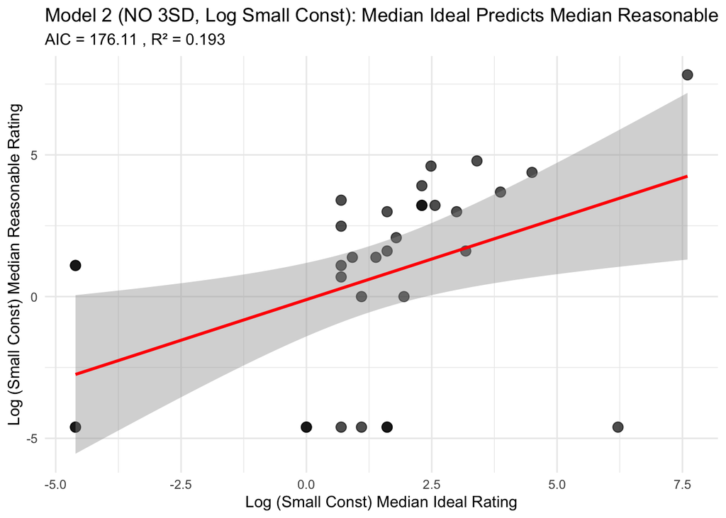

```r
print(plot2_median_no3sd_smallval)
```

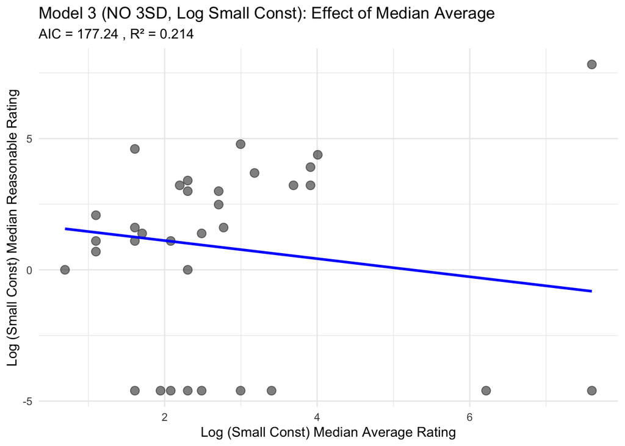

```r
print(plot3_median_no3sd_smallval)
```

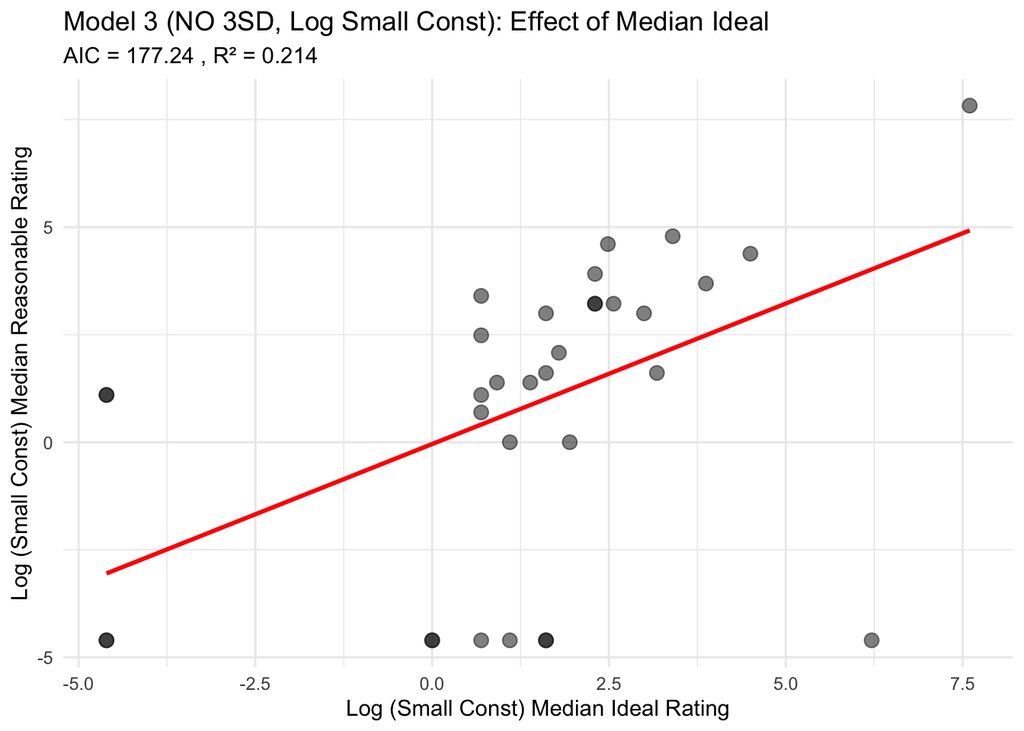

```r
print(plot4_median_no3sd_smallval)
```

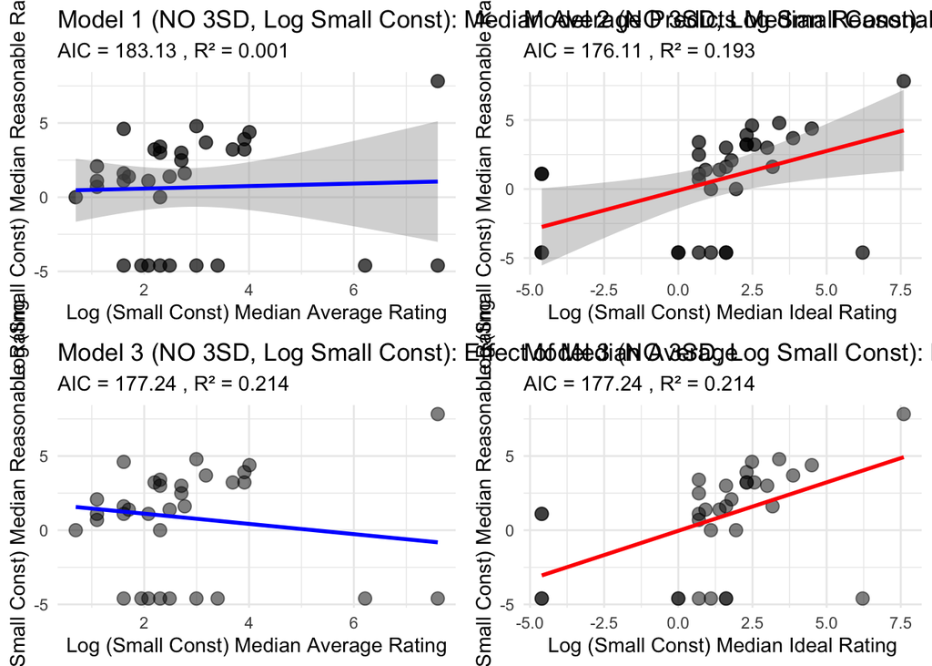

```r
# Save plots
ggsave("model1_median_avg_reas_no3sd_smallval.png", plot1_median_no3sd_smallval, width = 8, height = 6, dpi = 300)
ggsave("model2_median_ideal_reas_no3sd_smallval.png", plot2_median_no3sd_smallval, width = 8, height = 6, dpi = 300)
ggsave("model3_median_avg_eff_no3sd_smallval.png", plot3_median_no3sd_smallval, width = 8, height = 6, dpi = 300)
ggsave("model3_median_ideal_eff_no3sd_smallval.png", plot4_median_no3sd_smallval, width = 8, height = 6, dpi = 300)

# Combined plot layout
grid_plots_median_no3sd_smallval <- grid.arrange(plot1_median_no3sd_smallval, plot2_median_no3sd_smallval, plot3_median_no3sd_smallval, plot4_median_no3sd_smallval, ncol = 2)
```

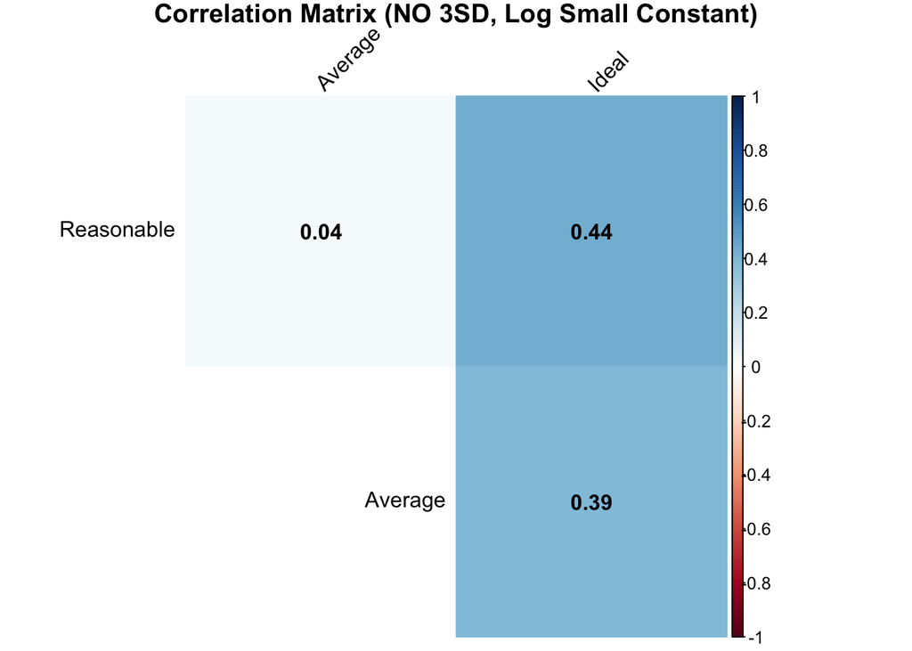

```r
ggsave("all_median_regression_plots_no3sd_smallval.png", grid_plots_median_no3sd_smallval, width = 14, height = 10, dpi = 300)

# Correlation matrix
cor_data_no3sd_smallval <- dataforAICMedians_no3sd_smallval[complete.cases(dataforAICMedians_no3sd_smallval) & is.finite(rowSums(dataforAICMedians_no3sd_smallval)),]
if(nrow(cor_data_no3sd_smallval) > 1) {
 cor_matrix_no3sd_smallval <- cor(cor_data_no3sd_smallval, use = "complete.obs")
 corrplot(cor_matrix_no3sd_smallval, method = "color", type = "upper", addCoef.col = "black", tl.col = "black", tl.srt = 45, diag = FALSE, title = "Correlation Matrix (NO 3SD, Log Small Constant)", mar = c(0,0,1,0))
} else {
 cat("Not enough valid data points for correlation matrix (NO 3SD, Log Small Constant).\n")
}
```

```r
# Coefficient tables
model1_coefs_no3sd_smallval <- get_model_coefs(Model1Medians_no3sd_smallval)
model2_coefs_no3sd_smallval <- get_model_coefs(Model2Medians_no3sd_smallval)
model3_coefs_no3sd_smallval <- get_model_coefs(Model3Medians_no3sd_smallval)
model1_coefs_no3sd_smallval$p_value <- sapply(model1_coefs_no3sd_smallval$p_value, format_pvalue)
model2_coefs_no3sd_smallval$p_value <- sapply(model2_coefs_no3sd_smallval$p_value, format_pvalue)
model3_coefs_no3sd_smallval$p_value <- sapply(model3_coefs_no3sd_smallval$p_value, format_pvalue)

kable(model1_coefs_no3sd_smallval, caption = "Model 1 Coeffs (NO 3SD, Log Small Const)") %>% kable_styling()
```

Model 1 Coeffs (NO 3SD, Log Small Const)

|  | Term | Estimate | Std_Error | t_value | p_value |
| --- | --- | --- | --- | --- | --- |
| (Intercept) | (Intercept) | 0.4106407 | 1.2707513 | 0.3231480 | 0.749 |
| Average | Average | 0.0844553 | 0.3932404 | 0.2147677 | 0.831 |

```r
kable(model2_coefs_no3sd_smallval, caption = "Model 2 Coeffs (NO 3SD, Log Small Const)") %>% kable_styling()
```

Model 2 Coeffs (NO 3SD, Log Small Const)

|  | Term | Estimate | Std_Error | t_value | p_value |
| --- | --- | --- | --- | --- | --- |
| (Intercept) | (Intercept) | -0.1073312 | 0.6357038 | -0.1688384 | 0.867 |
| Ideal | Ideal | 0.5729619 | 0.2105944 | 2.7206895 | 0.011 |

```r
kable(model3_coefs_no3sd_smallval, caption = "Model 3 Coeffs (NO 3SD, Log Small Const)") %>% kable_styling()
```

Model 3 Coeffs (NO 3SD, Log Small Const)

|  | Term | Estimate | Std_Error | t_value | p_value |
| --- | --- | --- | --- | --- | --- |
| (Intercept) | (Intercept) | 0.7510611 | 1.1525172 | 0.6516702 | 0.520 |
| Average | Average | -0.3446637 | 0.3854503 | -0.8941845 | 0.378 |
| Ideal | Ideal | 0.6532777 | 0.2295785 | 2.8455532 | 0.008 |

```r
# Print model summaries
cat("\nModel Summaries (NO 3SD, Log Small Constant):\n")
```

```
##
## Model Summaries (NO 3SD, Log Small Constant):
```

```r
print(summary(Model1Medians_no3sd_smallval))
```

```
##
## Call:
## lm(formula = Reasonable ~ Average, data = dataforAICMedians_no3sd_smallval)
##
## Residuals:
##     Min      1Q  Median      3Q     Max
## -5.6577 -5.1517  0.8317  2.4967  6.7715
##
## Coefficients:
##             Estimate Std. Error t value Pr(>|t|)
## (Intercept)  0.41064    1.27075   0.323    0.749
## Average      0.08446    0.39324   0.215    0.831
##
## Residual standard error: 3.655 on 31 degrees of freedom
## Multiple R-squared:  0.001486,   Adjusted R-squared:  -0.03072
## F-statistic: 0.04613 on 1 and 31 DF,  p-value: 0.8314
```

```r
print(summary(Model2Medians_no3sd_smallval))
```

```
##
## Call:
## lm(formula = Reasonable ~ Ideal, data = dataforAICMedians_no3sd_smallval)
##
## Residuals:
##     Min      1Q  Median      3Q     Max
## -8.0586 -1.8593  0.9686  2.1809  3.8445
##
## Coefficients:
##             Estimate Std. Error t value Pr(>|t|)
## (Intercept)  -0.1073     0.6357  -0.169   0.8670
## Ideal         0.5730     0.2106   2.721   0.0106 *
## ---
## Signif. codes:  0 '***' 0.001 '**' 0.01 '*' 0.05 '.' 0.1 ' ' 1
##
## Residual standard error: 3.286 on 31 degrees of freedom
## Multiple R-squared:  0.1928, Adjusted R-squared:  0.1667
## F-statistic: 7.402 on 1 and 31 DF,  p-value: 0.01059
```

```r
print(summary(Model3Medians_no3sd_smallval))
```

```
##
## Call:
## lm(formula = Reasonable ~ Average + Ideal, data = dataforAICMedians_no3sd_smallval)
##
## Residuals:
##     Min      1Q  Median      3Q     Max
## -6.7963 -1.2299  0.6114  2.2144  4.7272
##
## Coefficients:
##             Estimate Std. Error t value Pr(>|t|)
## (Intercept)   0.7511     1.1525   0.652  0.51958
## Average      -0.3447     0.3855  -0.894  0.37834
## Ideal         0.6533     0.2296   2.846  0.00792 **
## ---
## Signif. codes:  0 '***' 0.001 '**' 0.01 '*' 0.05 '.' 0.1 ' ' 1
##
## Residual standard error: 3.297 on 30 degrees of freedom
## Multiple R-squared:  0.2137, Adjusted R-squared:  0.1613
## F-statistic: 4.077 on 2 and 30 DF,  p-value: 0.02715
```

#### 4b. (Plus one to all values): Plots and Reporting (NO 3SD Removal)

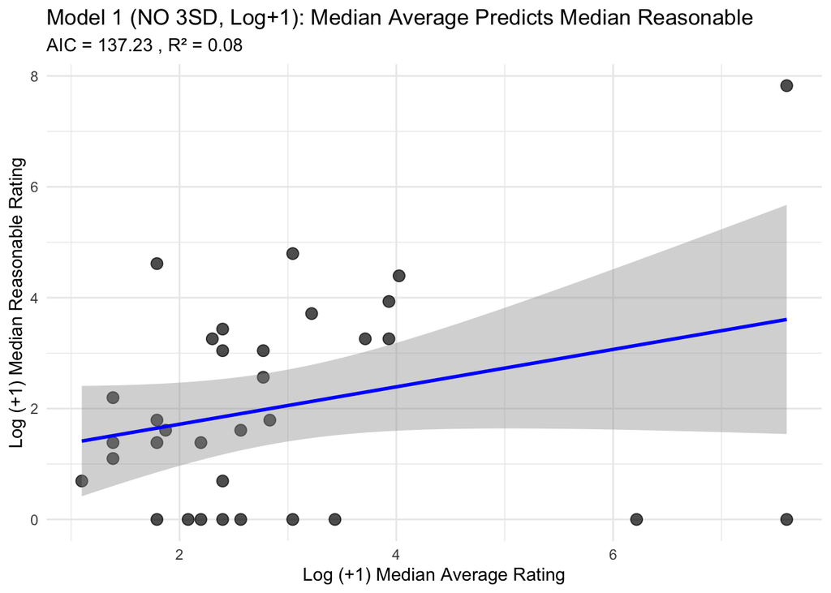

```r
# Average Median vs Reasonable Median
plot1_median_no3sd_plusone <- ggplot(dataforAICMedians_no3sd_plusone, aes(x = Average, y = Reasonable)) +
  geom_point(size = 3, alpha = 0.7) +
  geom_smooth(method = "lm", se = TRUE, color = "blue") +
  labs(title = "Model 1 (NO 3SD, Log+1): Median Average Predicts Median Reasonable",
       subtitle = paste("AIC =", round(AIC1Medians_no3sd_plusone, 2), ", R² =", round(r2_model1_median_no3sd_plusone, 3)),
       x = "Log (+1) Median Average Rating",
       y = "Log (+1) Median Reasonable Rating") +
  theme_minimal() # Add theme elements

# Ideal Median vs Reasonable Median
plot2_median_no3sd_plusone <- ggplot(dataforAICMedians_no3sd_plusone, aes(x = Ideal, y = Reasonable)) +
   geom_point(size = 3, alpha = 0.7) +
   geom_smooth(method = "lm", se = TRUE, color = "red") +
   labs(title = "Model 2 (NO 3SD, Log+1): Median Ideal Predicts Median Reasonable",
        subtitle = paste("AIC =", round(AIC2Medians_no3sd_plusone, 2), ", R² =", round(r2_model2_median_no3sd_plusone, 3)),
        x = "Log (+1) Median Ideal Rating",
        y = "Log (+1) Median Reasonable Rating") +
  theme_minimal() # Add theme elements

# Model 3 visualizations (effect of average, holding ideal constant)
new_data_median_no3sd_plusone <- expand.grid(
  Average = seq(min(dataforAICMedians_no3sd_plusone$Average, na.rm=TRUE), max(dataforAICMedians_no3sd_plusone$Average, na.rm=TRUE), length.out = 100),
  Ideal = median(dataforAICMedians_no3sd_plusone$Ideal, na.rm=TRUE)
)
new_data_median_no3sd_plusone <- new_data_median_no3sd_plusone[is.finite(new_data_median_no3sd_plusone$Average) & is.finite(new_data_median_no3sd_plusone$Ideal),]
if(nrow(new_data_median_no3sd_plusone)>0){
    new_data_median_no3sd_plusone$predicted_reasonable <- predict(Model3Medians_no3sd_plusone, newdata = new_data_median_no3sd_plusone)
} else {
    new_data_median_no3sd_plusone <- data.frame(Average=numeric(), Ideal=numeric(), predicted_reasonable=numeric())
}
plot3_median_no3sd_plusone <- ggplot(dataforAICMedians_no3sd_plusone, aes(x = Average, y = Reasonable)) +
  geom_point(size = 3, alpha = 0.5) +
  geom_line(data = new_data_median_no3sd_plusone, aes(y = predicted_reasonable), color = "blue", size = 1) +
  labs(title = "Model 3 (NO 3SD, Log+1): Effect of Median Average",
       subtitle = paste("AIC =", round(AIC3Medians_no3sd_plusone, 2), ", R² =", round(r2_model3_median_no3sd_plusone, 3)),
       x = "Log (+1) Median Average Rating",
       y = "Log (+1) Median Reasonable Rating") +
  theme_minimal() # Add theme elements

# Model 3 visualization (effect of ideal, holding average constant)
new_data2_median_no3sd_plusone <- expand.grid(
  Average = median(dataforAICMedians_no3sd_plusone$Average, na.rm=TRUE),
  Ideal = seq(min(dataforAICMedians_no3sd_plusone$Ideal, na.rm=TRUE), max(dataforAICMedians_no3sd_plusone$Ideal, na.rm=TRUE), length.out = 100)
)
new_data2_median_no3sd_plusone <- new_data2_median_no3sd_plusone[is.finite(new_data2_median_no3sd_plusone$Average) & is.finite(new_data2_median_no3sd_plusone$Ideal),]
if(nrow(new_data2_median_no3sd_plusone)>0){
    new_data2_median_no3sd_plusone$predicted_reasonable <- predict(Model3Medians_no3sd_plusone, newdata = new_data2_median_no3sd_plusone)
} else {
     new_data2_median_no3sd_plusone <- data.frame(Average=numeric(), Ideal=numeric(), predicted_reasonable=numeric())
}
plot4_median_no3sd_plusone <- ggplot(dataforAICMedians_no3sd_plusone, aes(x = Ideal, y = Reasonable)) +
   geom_point(size = 3, alpha = 0.5) +
   geom_line(data = new_data2_median_no3sd_plusone, aes(y = predicted_reasonable), color = "red", size = 1) +
   labs(title = "Model 3 (NO 3SD, Log+1): Effect of Median Ideal",
        subtitle = paste("AIC =", round(AIC3Medians_no3sd_plusone, 2), ", R² =", round(r2_model3_median_no3sd_plusone, 3)),
        x = "Log (+1) Median Ideal Rating",
        y = "Log (+1) Median Reasonable Rating") +
  theme_minimal() # Add theme elements

# Display plots
print(plot1_median_no3sd_plusone)
```

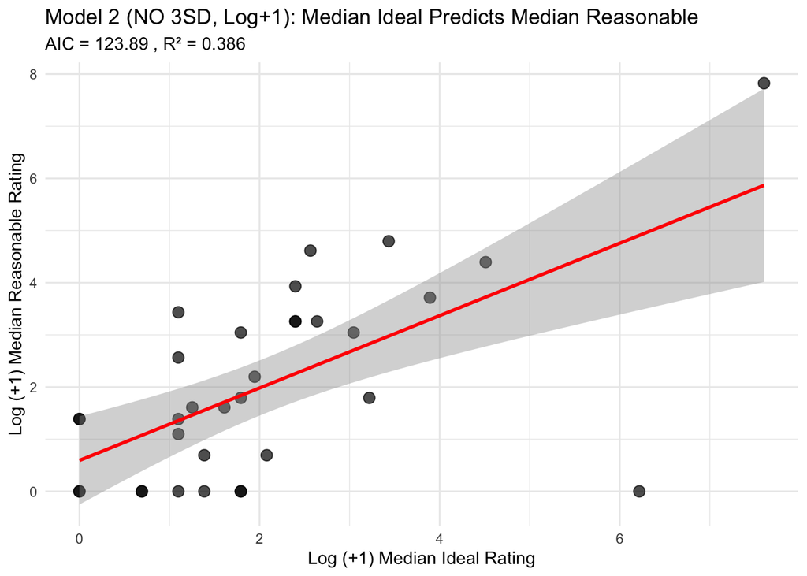

```r
print(plot2_median_no3sd_plusone)
```

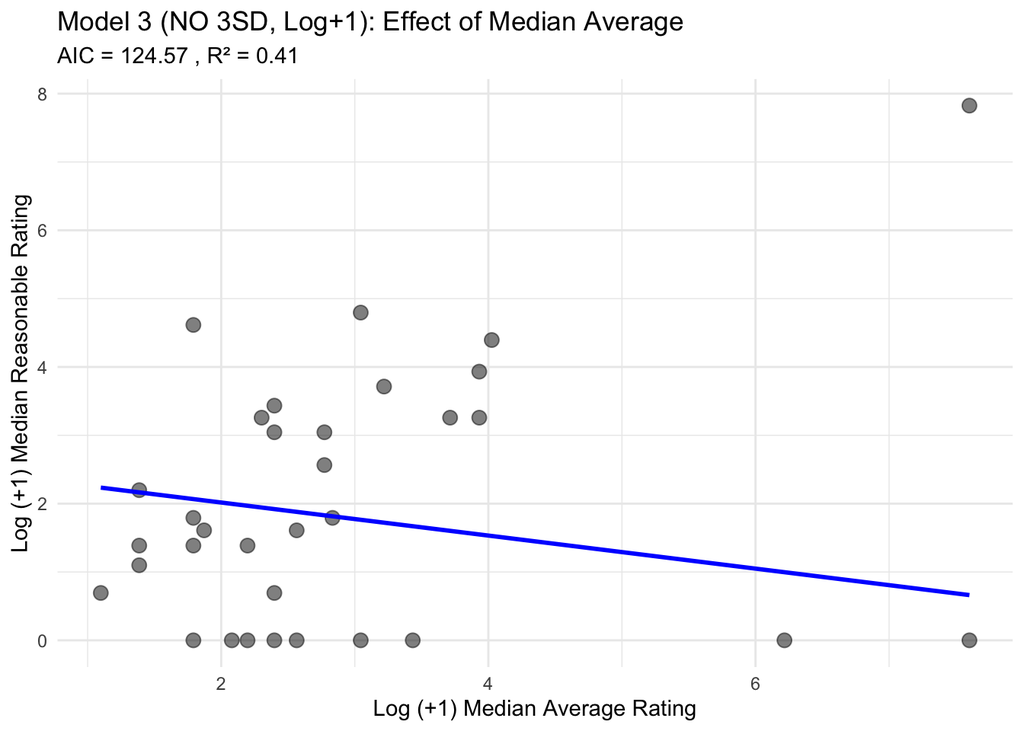

```r
print(plot3_median_no3sd_plusone)
```

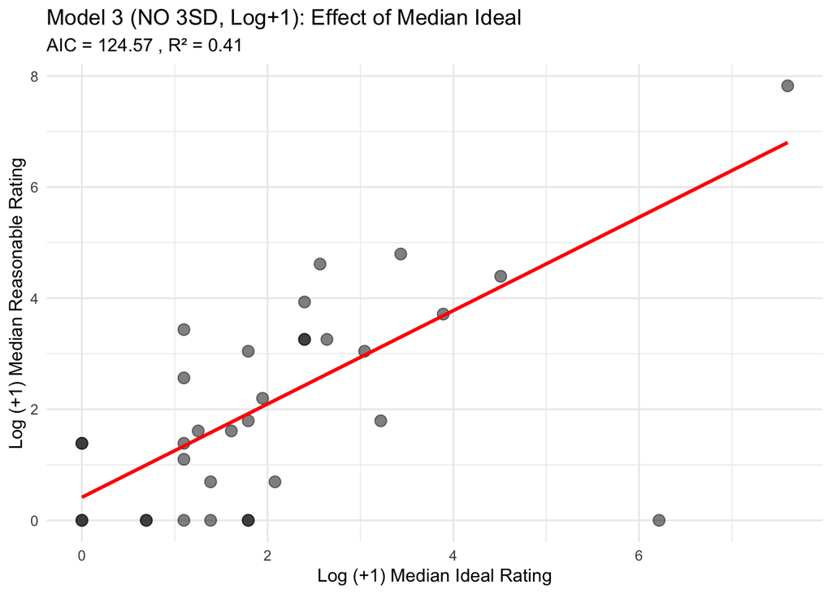

```r
print(plot4_median_no3sd_plusone)
```

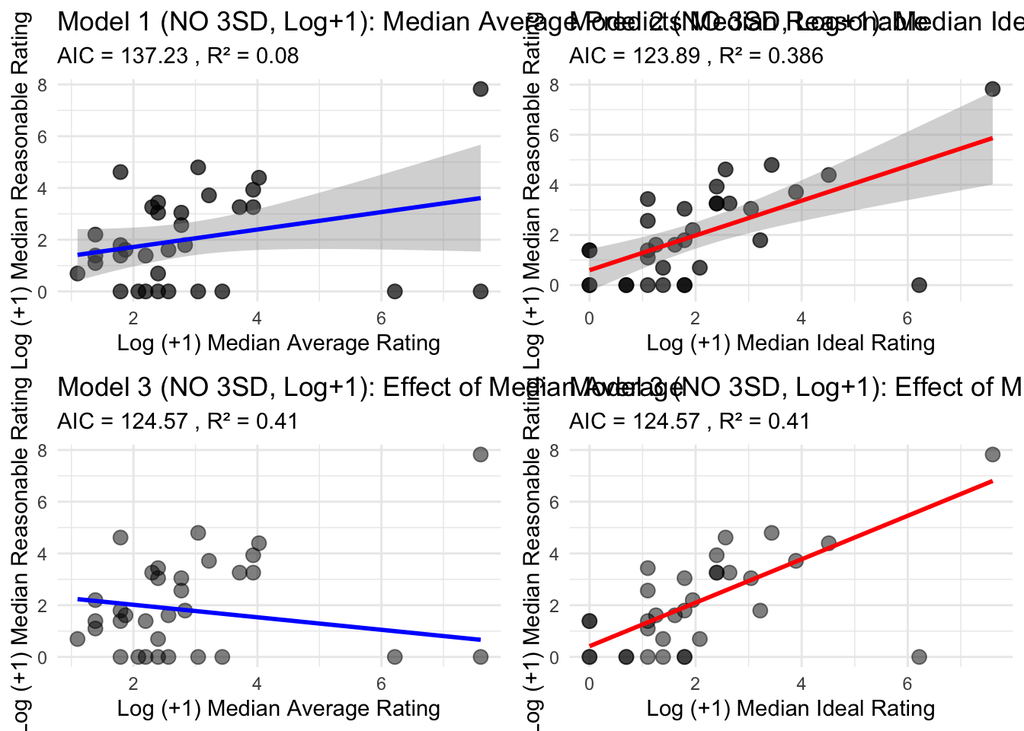

```r
# Save plots
ggsave("model1_median_avg_reas_no3sd_plusone.png", plot1_median_no3sd_plusone, width = 8, height = 6, dpi = 300)
ggsave("model2_median_ideal_reas_no3sd_plusone.png", plot2_median_no3sd_plusone, width = 8, height = 6, dpi = 300)
ggsave("model3_median_avg_eff_no3sd_plusone.png", plot3_median_no3sd_plusone, width = 8, height = 6, dpi = 300)
ggsave("model3_median_ideal_eff_no3sd_plusone.png", plot4_median_no3sd_plusone, width = 8, height = 6, dpi = 300)

# Combined plot layout
grid_plots_median_no3sd_plusone <- grid.arrange(plot1_median_no3sd_plusone, plot2_median_no3sd_plusone, plot3_median_no3sd_plusone, plot4_median_no3sd_plusone, ncol = 2)
```

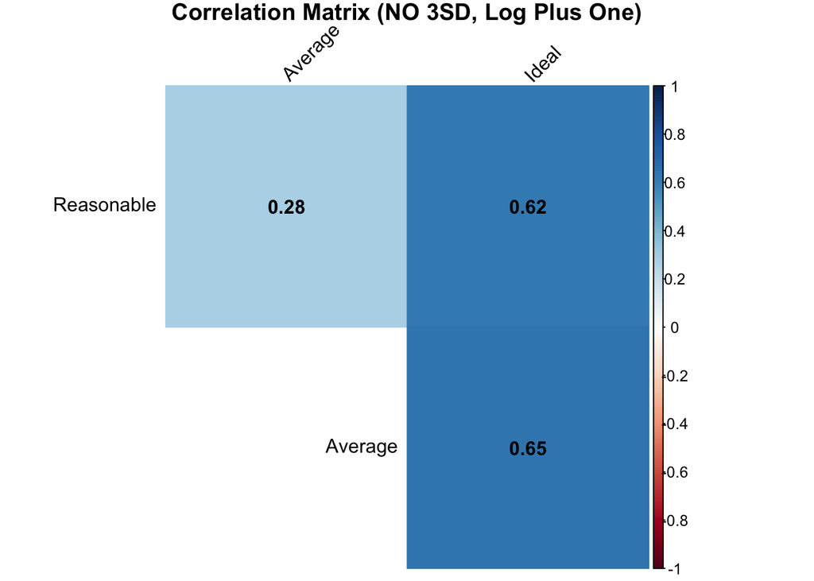

```r
ggsave("all_median_regression_plots_no3sd_plusone.png", grid_plots_median_no3sd_plusone, width = 14, height = 10, dpi = 300)

# Correlation matrix
cor_data_no3sd_plusone <- dataforAICMedians_no3sd_plusone[complete.cases(dataforAICMedians_no3sd_plusone) & is.finite(rowSums(dataforAICMedians_no3sd_plusone)),]
if(nrow(cor_data_no3sd_plusone) > 1) {
 cor_matrix_no3sd_plusone <- cor(cor_data_no3sd_plusone, use = "complete.obs")
 corrplot(cor_matrix_no3sd_plusone, method = "color", type = "upper", addCoef.col = "black", tl.col = "black", tl.srt = 45, diag = FALSE, title = "Correlation Matrix (NO 3SD, Log Plus One)", mar = c(0,0,1,0))
} else {
 cat("Not enough valid data points for correlation matrix (NO 3SD, Log Plus One).\n")
}
```

```r
# Coefficient tables
model1_coefs_no3sd_plusone <- get_model_coefs(Model1Medians_no3sd_plusone)
model2_coefs_no3sd_plusone <- get_model_coefs(Model2Medians_no3sd_plusone)
model3_coefs_no3sd_plusone <- get_model_coefs(Model3Medians_no3sd_plusone)
model1_coefs_no3sd_plusone$p_value <- sapply(model1_coefs_no3sd_plusone$p_value, format_pvalue)
model2_coefs_no3sd_plusone$p_value <- sapply(model2_coefs_no3sd_plusone$p_value, format_pvalue)
model3_coefs_no3sd_plusone$p_value <- sapply(model3_coefs_no3sd_plusone$p_value, format_pvalue)

kable(model1_coefs_no3sd_plusone, caption = "Model 1 Coeffs (NO 3SD, Log Plus One)") %>% kable_styling()
```

Model 1 Coeffs (NO 3SD, Log Plus One)

|  | Term | Estimate | Std_Error | t_value | p_value |
| --- | --- | --- | --- | --- | --- |
| (Intercept) | (Intercept) | 1.042822 | 0.6753460 | 1.544130 | 0.133 |
| Average | Average | 0.337387 | 0.2050497 | 1.645391 | 0.110 |

```r
kable(model2_coefs_no3sd_plusone, caption = "Model 2 Coeffs (NO 3SD, Log Plus One)") %>% kable_styling()
```

Model 2 Coeffs (NO 3SD, Log Plus One)

|  | Term | Estimate | Std_Error | t_value | p_value |
| --- | --- | --- | --- | --- | --- |
| (Intercept) | (Intercept) | 0.5933890 | 0.4148946 | 1.430216 | 0.163 |
| Ideal | Ideal | 0.6938761 | 0.1571257 | 4.416058 | < .001 |

```r
kable(model3_coefs_no3sd_plusone, caption = "Model 3 Coeffs (NO 3SD, Log Plus One)") %>% kable_styling()
```

Model 3 Coeffs (NO 3SD, Log Plus One)

|  | Term | Estimate | Std_Error | t_value | p_value |
| --- | --- | --- | --- | --- | --- |
| (Intercept) | (Intercept) | 0.9942295 | 0.5499046 | 1.808004 | 0.081 |
| Average | Average | -0.2418391 | 0.2187698 | -1.105450 | 0.278 |
| Ideal | Ideal | 0.8404968 | 0.2051946 | 4.096097 | < .001 |

```r
# Print model summaries
cat("\nModel Summaries (NO 3SD, Log Plus One):\n")
```

```
##
## Model Summaries (NO 3SD, Log Plus One):
```

```r
print(summary(Model1Medians_no3sd_plusone))
```

```
##
## Call:
## lm(formula = Reasonable ~ Average, data = dataforAICMedians_no3sd_plusone)
##
## Residuals:
##     Min      1Q  Median      3Q     Max
## -3.6074 -1.6473 -0.1242  1.1927  4.2170
##
## Coefficients:
##             Estimate Std. Error t value Pr(>|t|)
## (Intercept)   1.0428     0.6753   1.544    0.133
## Average       0.3374     0.2050   1.645    0.110
##
## Residual standard error: 1.823 on 31 degrees of freedom
## Multiple R-squared:  0.08032,    Adjusted R-squared:  0.05065
## F-statistic: 2.707 on 1 and 31 DF,  p-value: 0.11
```

```r
print(summary(Model2Medians_no3sd_plusone))
```

```
##
## Call:
## lm(formula = Reasonable ~ Ideal, data = dataforAICMedians_no3sd_plusone)
##
## Residuals:
##     Min      1Q  Median      3Q     Max
## -4.9069 -1.0351  0.1468  1.0009  2.2420
##
## Coefficients:
##             Estimate Std. Error t value Pr(>|t|)
## (Intercept)   0.5934     0.4149   1.430 0.162658
## Ideal         0.6939     0.1571   4.416 0.000114 ***
## ---
## Signif. codes:  0 '***' 0.001 '**' 0.01 '*' 0.05 '.' 0.1 ' ' 1
##
## Residual standard error: 1.49 on 31 degrees of freedom
## Multiple R-squared:  0.3862, Adjusted R-squared:  0.3664
## F-statistic:  19.5 on 1 and 31 DF,  p-value: 0.0001136
```

```r
print(summary(Model3Medians_no3sd_plusone))
```

```
##
## Call:
## lm(formula = Reasonable ~ Average + Ideal, data = dataforAICMedians_no3sd_plusone)
##
## Residuals:
##     Min      1Q  Median      3Q     Max
## -4.3810 -0.9969  0.0149  0.9966  2.2796
##
## Coefficients:
##             Estimate Std. Error t value Pr(>|t|)
## (Intercept)   0.9942     0.5499   1.808 0.080642 .
## Average      -0.2418     0.2188  -1.105 0.277752
## Ideal         0.8405     0.2052   4.096 0.000293 ***
## ---
## Signif. codes:  0 '***' 0.001 '**' 0.01 '*' 0.05 '.' 0.1 ' ' 1
##
## Residual standard error: 1.484 on 30 degrees of freedom
## Multiple R-squared:  0.4102, Adjusted R-squared:  0.3709
## F-statistic: 10.43 on 2 and 30 DF,  p-value: 0.0003637
```

# Analysis 3 [WITH 3 SD removed]: Overall results, with median ratings

#### 1. Compute the median rating

```r
# Calculate medians from data filtered for attention check AND 3SD outliers
column_medians_average_3sd <- sapply(Data_All_Average_Filtered[, question_cols], median, na.rm = TRUE)
column_medians_ideal_3sd <- sapply(Data_All_Ideal_Filtered[, question_cols], median, na.rm = TRUE)
column_medians_reasonable_3sd <- sapply(Data_All_Reasonable_Filtered[, question_cols], median, na.rm = TRUE)

# Create a dataframe for the medians
medians_df_3sd <- data.frame(
  Question = names(column_medians_average_3sd),
  Average = column_medians_average_3sd,
  Ideal = column_medians_ideal_3sd,
  Reasonable = column_medians_reasonable_3sd
)

# Display the medians for each question
kable(medians_df_3sd, caption = "Median Values (WITH 3SD Removal)") %>%
  kable_styling(bootstrap_options = c("striped", "hover", "condensed"), full_width = F)
```

Median Values (WITH 3SD Removal)

|  | Question | Average | Ideal | Reasonable |
| --- | --- | --- | --- | --- |
| q1 | q1 | 3.0 | 2 | 2.0 |
| q2 | q2 | 7.0 | 2 | 0.0 |
| q3 | q3 | 3.0 | 6 | 8.0 |
| q4 | q4 | 2000.0 | 2000 | 2500.0 |
| q5 | q5 | 20.0 | 30 | 120.0 |
| q6 | q6 | 10.0 | 1 | 0.0 |
| q7 | q7 | 15.0 | 5 | 20.0 |
| q8 | q8 | 5.0 | 12 | 100.0 |
| q9 | q9 | 5.0 | 3 | 0.0 |
| q10 | q10 | 5.0 | 0 | 3.0 |
| q11 | q11 | 500.0 | 0 | 0.0 |
| q12 | q12 | 30.0 | 0 | 0.0 |
| q13 | q13 | 40.0 | 10 | 25.0 |
| q14 | q14 | 10.0 | 2 | 30.0 |
| q15 | q15 | 8.0 | 10 | 25.0 |
| q16 | q16 | 4.0 | 5 | 5.0 |
| q17 | q17 | 3.0 | 0 | 3.0 |
| q18 | q18 | 10.0 | 1 | 12.0 |
| q20 | q20 | 20.0 | 0 | 0.0 |
| q21 | q21 | 8.0 | 5 | 0.0 |
| q22 | q22 | 7.0 | 7 | 1.0 |
| q23 | q23 | 2.0 | 2 | 1.0 |
| q24 | q24 | 15.0 | 24 | 5.0 |
| q25 | q25 | 2000.0 | 500 | 0.0 |
| q26 | q26 | 8.0 | 2 | 3.0 |
| q27 | q27 | 11.5 | 4 | 0.0 |
| q28 | q28 | 10.0 | 20 | 20.0 |
| q29 | q29 | 54.5 | 90 | 80.0 |
| q30 | q30 | 12.0 | 3 | 4.0 |
| q31 | q31 | 50.0 | 10 | 25.0 |
| q32 | q32 | 24.0 | 48 | 40.0 |
| q33 | q33 | 5.0 | 2 | 3.5 |
| q34 | q34 | 50.0 | 5 | 48.0 |

#### 2a. (Small constant inf values): Convert median responses to a natural log scale (WITH 3SD Removal)

```r
# Apply the log function: log_smallvalue (defined earlier)
log_medians_average_3sd_smallval <- log_smallvalue(column_medians_average_3sd)
log_medians_ideal_3sd_smallval <- log_smallvalue(column_medians_ideal_3sd)
log_medians_reasonable_3sd_smallval <- log_smallvalue(column_medians_reasonable_3sd)

# Create a dataframe for the log medians
log_medians_df_3sd_smallval <- data.frame(
  Question = names(log_medians_average_3sd_smallval),
  Average = log_medians_average_3sd_smallval,
  Ideal = log_medians_ideal_3sd_smallval,
  Reasonable = log_medians_reasonable_3sd_smallval
)

# Display the log medians
kable(log_medians_df_3sd_smallval, caption = "Log-Transformed (Small Constant) Median Values (WITH 3SD Removal)") %>%
  kable_styling(bootstrap_options = c("striped", "hover", "condensed"), full_width = F)
```

Log-Transformed (Small Constant) Median Values (WITH 3SD Removal)

|  | Question | Average | Ideal | Reasonable |
| --- | --- | --- | --- | --- |
| q1 | q1 | 1.0986123 | 0.6931472 | 0.6931472 |
| q2 | q2 | 1.9459101 | 0.6931472 | -4.6051702 |
| q3 | q3 | 1.0986123 | 1.7917595 | 2.0794415 |
| q4 | q4 | 7.6009025 | 7.6009025 | 7.8240460 |
| q5 | q5 | 2.9957323 | 3.4011974 | 4.7874917 |
| q6 | q6 | 2.3025851 | 0.0000000 | -4.6051702 |
| q7 | q7 | 2.7080502 | 1.6094379 | 2.9957323 |
| q8 | q8 | 1.6094379 | 2.4849066 | 4.6051702 |
| q9 | q9 | 1.6094379 | 1.0986123 | -4.6051702 |
| q10 | q10 | 1.6094379 | -4.6051702 | 1.0986123 |
| q11 | q11 | 6.2146081 | -4.6051702 | -4.6051702 |
| q12 | q12 | 3.4011974 | -4.6051702 | -4.6051702 |
| q13 | q13 | 3.6888795 | 2.3025851 | 3.2188758 |
| q14 | q14 | 2.3025851 | 0.6931472 | 3.4011974 |
| q15 | q15 | 2.0794415 | 2.3025851 | 3.2188758 |
| q16 | q16 | 1.3862944 | 1.6094379 | 1.6094379 |
| q17 | q17 | 1.0986123 | -4.6051702 | 1.0986123 |
| q18 | q18 | 2.3025851 | 0.0000000 | 2.4849066 |
| q20 | q20 | 2.9957323 | -4.6051702 | -4.6051702 |
| q21 | q21 | 2.0794415 | 1.6094379 | -4.6051702 |
| q22 | q22 | 1.9459101 | 1.9459101 | 0.0000000 |
| q23 | q23 | 0.6931472 | 0.6931472 | 0.0000000 |
| q24 | q24 | 2.7080502 | 3.1780538 | 1.6094379 |
| q25 | q25 | 7.6009025 | 6.2146081 | -4.6051702 |
| q26 | q26 | 2.0794415 | 0.6931472 | 1.0986123 |
| q27 | q27 | 2.4423470 | 1.3862944 | -4.6051702 |
| q28 | q28 | 2.3025851 | 2.9957323 | 2.9957323 |
| q29 | q29 | 3.9982007 | 4.4998097 | 4.3820266 |
| q30 | q30 | 2.4849066 | 1.0986123 | 1.3862944 |
| q31 | q31 | 3.9120230 | 2.3025851 | 3.2188758 |
| q32 | q32 | 3.1780538 | 3.8712010 | 3.6888795 |
| q33 | q33 | 1.6094379 | 0.6931472 | 1.2527630 |
| q34 | q34 | 3.9120230 | 1.6094379 | 3.8712010 |

#### 2b. (Plus one to all values): Convert median responses to a natural log scale (WITH 3SD Removal)

```r
# Apply the log function: log_plus_one (defined earlier)
log_medians_average_3sd_plusone <- log_plus_one(column_medians_average_3sd)
log_medians_ideal_3sd_plusone <- log_plus_one(column_medians_ideal_3sd)
log_medians_reasonable_3sd_plusone <- log_plus_one(column_medians_reasonable_3sd)

# Create a dataframe for the log medians
log_medians_df_3sd_plusone <- data.frame(
  Question = names(log_medians_average_3sd_plusone),
  Average = log_medians_average_3sd_plusone,
  Ideal = log_medians_ideal_3sd_plusone,
  Reasonable = log_medians_reasonable_3sd_plusone
)

# Display the log medians
kable(log_medians_df_3sd_plusone, caption = "Log-Transformed (Plus One) Median Values (WITH 3SD Removal)") %>%
  kable_styling(bootstrap_options = c("striped", "hover", "condensed"), full_width = F)
```

Log-Transformed (Plus One) Median Values (WITH 3SD Removal)

|  | Question | Average | Ideal | Reasonable |
| --- | --- | --- | --- | --- |
| q1 | q1 | 1.386294 | 1.0986123 | 1.0986123 |
| q2 | q2 | 2.079442 | 1.0986123 | 0.0000000 |
| q3 | q3 | 1.386294 | 1.9459101 | 2.1972246 |
| q4 | q4 | 7.601402 | 7.6014023 | 7.8244459 |
| q5 | q5 | 3.044522 | 3.4339872 | 4.7957905 |
| q6 | q6 | 2.397895 | 0.6931472 | 0.0000000 |
| q7 | q7 | 2.772589 | 1.7917595 | 3.0445224 |
| q8 | q8 | 1.791759 | 2.5649494 | 4.6151205 |
| q9 | q9 | 1.791759 | 1.3862944 | 0.0000000 |
| q10 | q10 | 1.791759 | 0.0000000 | 1.3862944 |
| q11 | q11 | 6.216606 | 0.0000000 | 0.0000000 |
| q12 | q12 | 3.433987 | 0.0000000 | 0.0000000 |
| q13 | q13 | 3.713572 | 2.3978953 | 3.2580965 |
| q14 | q14 | 2.397895 | 1.0986123 | 3.4339872 |
| q15 | q15 | 2.197225 | 2.3978953 | 3.2580965 |
| q16 | q16 | 1.609438 | 1.7917595 | 1.7917595 |
| q17 | q17 | 1.386294 | 0.0000000 | 1.3862944 |
| q18 | q18 | 2.397895 | 0.6931472 | 2.5649494 |
| q20 | q20 | 3.044522 | 0.0000000 | 0.0000000 |
| q21 | q21 | 2.197225 | 1.7917595 | 0.0000000 |
| q22 | q22 | 2.079442 | 2.0794415 | 0.6931472 |
| q23 | q23 | 1.098612 | 1.0986123 | 0.6931472 |
| q24 | q24 | 2.772589 | 3.2188758 | 1.7917595 |
| q25 | q25 | 7.601402 | 6.2166061 | 0.0000000 |
| q26 | q26 | 2.197225 | 1.0986123 | 1.3862944 |
| q27 | q27 | 2.525729 | 1.6094379 | 0.0000000 |
| q28 | q28 | 2.397895 | 3.0445224 | 3.0445224 |
| q29 | q29 | 4.016383 | 4.5108595 | 4.3944492 |
| q30 | q30 | 2.564949 | 1.3862944 | 1.6094379 |
| q31 | q31 | 3.931826 | 2.3978953 | 3.2580965 |
| q32 | q32 | 3.218876 | 3.8918203 | 3.7135721 |
| q33 | q33 | 1.791759 | 1.0986123 | 1.5040774 |
| q34 | q34 | 3.931826 | 1.7917595 | 3.8918203 |

#### 3a. (Small constant inf values): Conduct three regressions and record AIC (WITH 3SD Removal)

```r
# Create data frame for regression
dataforAICMedians_3sd_smallval <- data.frame(
  Reasonable = log_medians_reasonable_3sd_smallval,
  Average = log_medians_average_3sd_smallval,
  Ideal = log_medians_ideal_3sd_smallval
)
# Filter out rows with non-finite values before regression
dataforAICMedians_3sd_smallval <- dataforAICMedians_3sd_smallval %>% filter(is.finite(Reasonable) & is.finite(Average) & is.finite(Ideal))


# Model I: Median Average predicts Median Reasonable
Model1Medians_3sd_smallval <- lm(Reasonable ~ Average, data = dataforAICMedians_3sd_smallval)
AIC1Medians_3sd_smallval <- AIC(Model1Medians_3sd_smallval)
r2_model1_median_3sd_smallval <- summary(Model1Medians_3sd_smallval)$r.squared

# Model II: Median Ideal predicts Median Reasonable
Model2Medians_3sd_smallval <- lm(Reasonable ~ Ideal, data = dataforAICMedians_3sd_smallval)
AIC2Medians_3sd_smallval <- AIC(Model2Medians_3sd_smallval)
r2_model2_median_3sd_smallval <- summary(Model2Medians_3sd_smallval)$r.squared

# Model III: Both Median Average and Median Ideal predict Median Reasonable
Model3Medians_3sd_smallval <- lm(Reasonable ~ Average + Ideal, data = dataforAICMedians_3sd_smallval)
AIC3Medians_3sd_smallval <- AIC(Model3Medians_3sd_smallval)
r2_model3_median_3sd_smallval <- summary(Model3Medians_3sd_smallval)$r.squared

# Create a regression summary dataframe
regression_summary_medians_3sd_smallval <- data.frame(
  Model = c("Average predicts Reasonable",
            "Ideal predicts Reasonable",
            "Average + Ideal predict Reasonable"),
  AIC = c(AIC1Medians_3sd_smallval, AIC2Medians_3sd_smallval, AIC3Medians_3sd_smallval),
  R_squared = c(r2_model1_median_3sd_smallval, r2_model2_median_3sd_smallval, r2_model3_median_3sd_smallval)
)

# Display the regression summary table
kable(regression_summary_medians_3sd_smallval, caption = "Regression Comparison (Median, WITH 3SD, Log Small Constant)") %>%
  kable_styling(bootstrap_options = c("striped", "hover", "condensed"), full_width = F)
```

Regression Comparison (Median, WITH 3SD, Log Small Constant)

| Model | AIC | R_squared |
| --- | --- | --- |
| Average predicts Reasonable | 183.1049 | 0.0011326 |
| Ideal predicts Reasonable | 174.6940 | 0.2258662 |
| Average + Ideal predict Reasonable | 175.8521 | 0.2453663 |

#### 3b. (Plus one to all values): Conduct three regressions and record AIC (WITH 3SD Removal)

```r
# Create data frame for regression
dataforAICMedians_3sd_plusone <- data.frame(
  Reasonable = log_medians_reasonable_3sd_plusone,
  Average = log_medians_average_3sd_plusone,
  Ideal = log_medians_ideal_3sd_plusone
)
# Filter out rows with non-finite values before regression
dataforAICMedians_3sd_plusone <- dataforAICMedians_3sd_plusone %>% filter(is.finite(Reasonable) & is.finite(Average) & is.finite(Ideal))


# Model I: Median Average predicts Median Reasonable
Model1Medians_3sd_plusone <- lm(Reasonable ~ Average, data = dataforAICMedians_3sd_plusone)
AIC1Medians_3sd_plusone <- AIC(Model1Medians_3sd_plusone)
r2_model1_median_3sd_plusone <- summary(Model1Medians_3sd_plusone)$r.squared

# Model II: Median Ideal predicts Median Reasonable
Model2Medians_3sd_plusone <- lm(Reasonable ~ Ideal, data = dataforAICMedians_3sd_plusone)
AIC2Medians_3sd_plusone <- AIC(Model2Medians_3sd_plusone)
r2_model2_median_3sd_plusone <- summary(Model2Medians_3sd_plusone)$r.squared

# Model III: Both Median Average and Median Ideal predict Median Reasonable
Model3Medians_3sd_plusone <- lm(Reasonable ~ Average + Ideal, data = dataforAICMedians_3sd_plusone)
AIC3Medians_3sd_plusone <- AIC(Model3Medians_3sd_plusone)
r2_model3_median_3sd_plusone <- summary(Model3Medians_3sd_plusone)$r.squared

# Create a regression summary dataframe
regression_summary_medians_3sd_plusone <- data.frame(
  Model = c("Average predicts Reasonable",
            "Ideal predicts Reasonable",
            "Average + Ideal predict Reasonable"),
  AIC = c(AIC1Medians_3sd_plusone, AIC2Medians_3sd_plusone, AIC3Medians_3sd_plusone),
  R_squared = c(r2_model1_median_3sd_plusone, r2_model2_median_3sd_plusone, r2_model3_median_3sd_plusone)
)

# Display the regression summary table
kable(regression_summary_medians_3sd_plusone, caption = "Regression Comparison (Median, WITH 3SD, Log Plus One)") %>%
  kable_styling(bootstrap_options = c("striped", "hover", "condensed"), full_width = F)
```

Regression Comparison (Median, WITH 3SD, Log Plus One)

| Model | AIC | R_squared |
| --- | --- | --- |
| Average predicts Reasonable | 137.1964 | 0.0808059 |
| Ideal predicts Reasonable | 124.2619 | 0.3788669 |
| Average + Ideal predict Reasonable | 125.3332 | 0.3961043 |

#### 4a. (Small constant inf values): Plots and Reporting (WITH 3SD Removal)

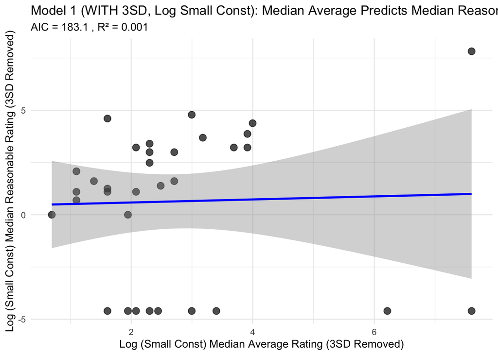

```r
# Average Median vs Reasonable Median
plot1_median_3sd_smallval <- ggplot(dataforAICMedians_3sd_smallval, aes(x = Average, y = Reasonable)) +
  geom_point(size = 3, alpha = 0.7) +
  geom_smooth(method = "lm", se = TRUE, color = "blue") +
  labs(title = "Model 1 (WITH 3SD, Log Small Const): Median Average Predicts Median Reasonable",
       subtitle = paste("AIC =", round(AIC1Medians_3sd_smallval, 2), ", R² =", round(r2_model1_median_3sd_smallval, 3)),
       x = "Log (Small Const) Median Average Rating (3SD Removed)",
       y = "Log (Small Const) Median Reasonable Rating (3SD Removed)") +
  theme_minimal() # Add theme elements as before

# Ideal Median vs Reasonable Median
plot2_median_3sd_smallval <- ggplot(dataforAICMedians_3sd_smallval, aes(x = Ideal, y = Reasonable)) +
   geom_point(size = 3, alpha = 0.7) +
   geom_smooth(method = "lm", se = TRUE, color = "red") +
   labs(title = "Model 2 (WITH 3SD, Log Small Const): Median Ideal Predicts Median Reasonable",
        subtitle = paste("AIC =", round(AIC2Medians_3sd_smallval, 2), ", R² =", round(r2_model2_median_3sd_smallval, 3)),
        x = "Log (Small Const) Median Ideal Rating (3SD Removed)",
        y = "Log (Small Const) Median Reasonable Rating (3SD Removed)") +
  theme_minimal() # Add theme elements

# Model 3 visualizations (effect of average, holding ideal constant)
new_data_median_3sd_smallval <- expand.grid(
  Average = seq(min(dataforAICMedians_3sd_smallval$Average, na.rm=TRUE), max(dataforAICMedians_3sd_smallval$Average, na.rm=TRUE), length.out = 100),
  Ideal = median(dataforAICMedians_3sd_smallval$Ideal, na.rm=TRUE)
)
new_data_median_3sd_smallval <- new_data_median_3sd_smallval[is.finite(new_data_median_3sd_smallval$Average) & is.finite(new_data_median_3sd_smallval$Ideal),]
if(nrow(new_data_median_3sd_smallval)>0){
    new_data_median_3sd_smallval$predicted_reasonable <- predict(Model3Medians_3sd_smallval, newdata = new_data_median_3sd_smallval)
} else {
    new_data_median_3sd_smallval <- data.frame(Average=numeric(), Ideal=numeric(), predicted_reasonable=numeric())
}
plot3_median_3sd_smallval <- ggplot(dataforAICMedians_3sd_smallval, aes(x = Average, y = Reasonable)) +
  geom_point(size = 3, alpha = 0.5) +
  geom_line(data = new_data_median_3sd_smallval, aes(y = predicted_reasonable), color = "blue", size = 1) +
  labs(title = "Model 3 (WITH 3SD, Log Small Const): Effect of Median Average",
       subtitle = paste("AIC =", round(AIC3Medians_3sd_smallval, 2), ", R² =", round(r2_model3_median_3sd_smallval, 3)),
       x = "Log (Small Const) Median Average Rating (3SD Removed)",
       y = "Log (Small Const) Median Reasonable Rating (3SD Removed)") +
  theme_minimal() # Add theme elements

# Model 3 visualization (effect of ideal, holding average constant)
new_data2_median_3sd_smallval <- expand.grid(
  Average = median(dataforAICMedians_3sd_smallval$Average, na.rm=TRUE),
  Ideal = seq(min(dataforAICMedians_3sd_smallval$Ideal, na.rm=TRUE), max(dataforAICMedians_3sd_smallval$Ideal, na.rm=TRUE), length.out = 100)
)
new_data2_median_3sd_smallval <- new_data2_median_3sd_smallval[is.finite(new_data2_median_3sd_smallval$Average) & is.finite(new_data2_median_3sd_smallval$Ideal),]
if(nrow(new_data2_median_3sd_smallval)>0){
    new_data2_median_3sd_smallval$predicted_reasonable <- predict(Model3Medians_3sd_smallval, newdata = new_data2_median_3sd_smallval)
} else {
     new_data2_median_3sd_smallval <- data.frame(Average=numeric(), Ideal=numeric(), predicted_reasonable=numeric())
}
plot4_median_3sd_smallval <- ggplot(dataforAICMedians_3sd_smallval, aes(x = Ideal, y = Reasonable)) +
   geom_point(size = 3, alpha = 0.5) +
   geom_line(data = new_data2_median_3sd_smallval, aes(y = predicted_reasonable), color = "red", size = 1) +
   labs(title = "Model 3 (WITH 3SD, Log Small Const): Effect of Median Ideal",
        subtitle = paste("AIC =", round(AIC3Medians_3sd_smallval, 2), ", R² =", round(r2_model3_median_3sd_smallval, 3)),
        x = "Log (Small Const) Median Ideal Rating (3SD Removed)",
        y = "Log (Small Const) Median Reasonable Rating (3SD Removed)") +
  theme_minimal() # Add theme elements

# Display plots
print(plot1_median_3sd_smallval)
```

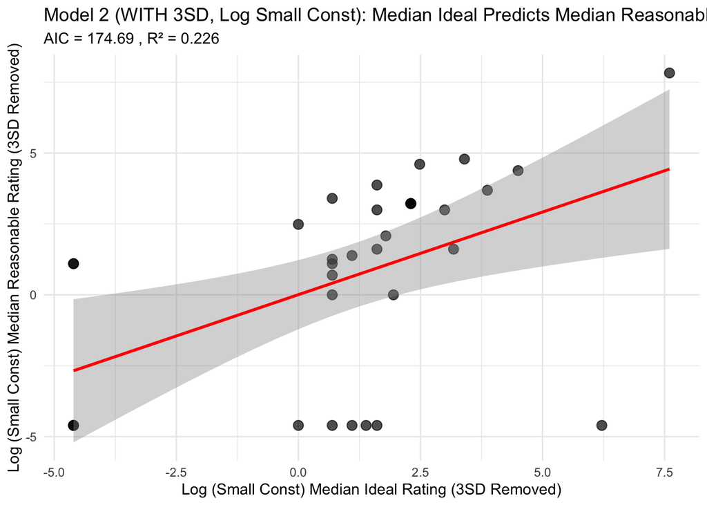

```r
print(plot2_median_3sd_smallval)
```

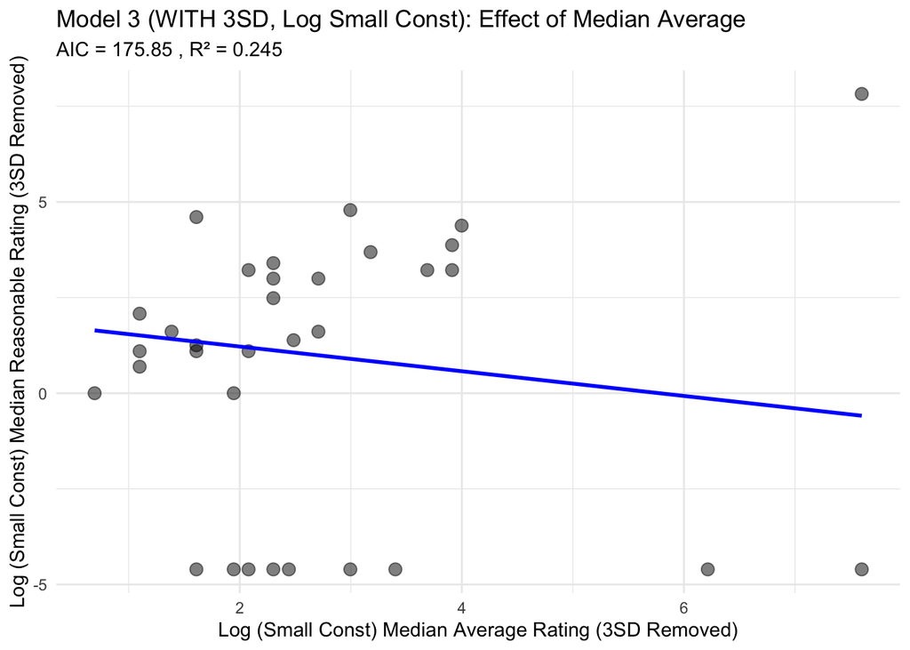

```r
print(plot3_median_3sd_smallval)
```

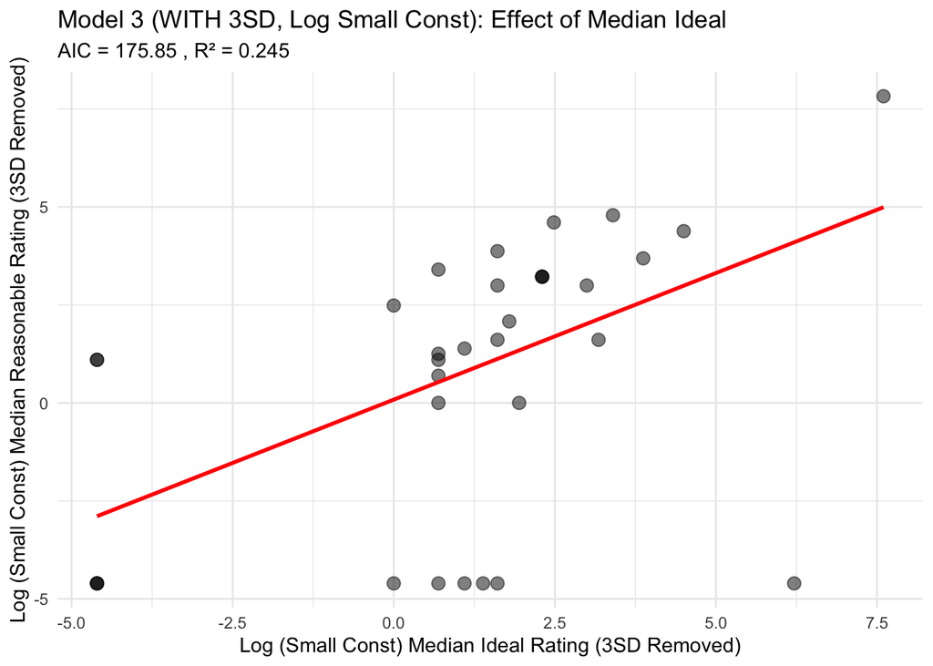

```r
print(plot4_median_3sd_smallval)
```

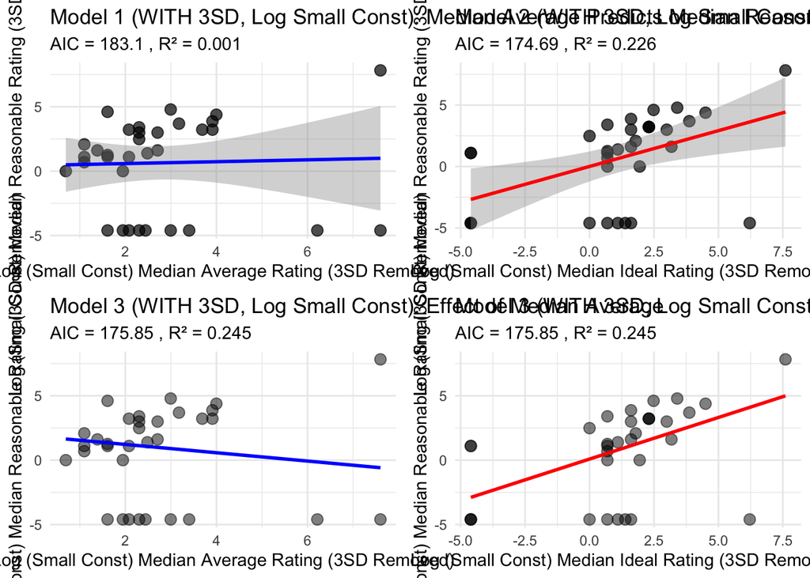

```r
# Save plots
ggsave("model1_median_avg_reas_3sd_smallval.png", plot1_median_3sd_smallval, width = 8, height = 6, dpi = 300)
ggsave("model2_median_ideal_reas_3sd_smallval.png", plot2_median_3sd_smallval, width = 8, height = 6, dpi = 300)
ggsave("model3_median_avg_eff_3sd_smallval.png", plot3_median_3sd_smallval, width = 8, height = 6, dpi = 300)
ggsave("model3_median_ideal_eff_3sd_smallval.png", plot4_median_3sd_smallval, width = 8, height = 6, dpi = 300)

# Combined plot layout
grid_plots_median_3sd_smallval <- grid.arrange(plot1_median_3sd_smallval, plot2_median_3sd_smallval, plot3_median_3sd_smallval, plot4_median_3sd_smallval, ncol = 2)
```

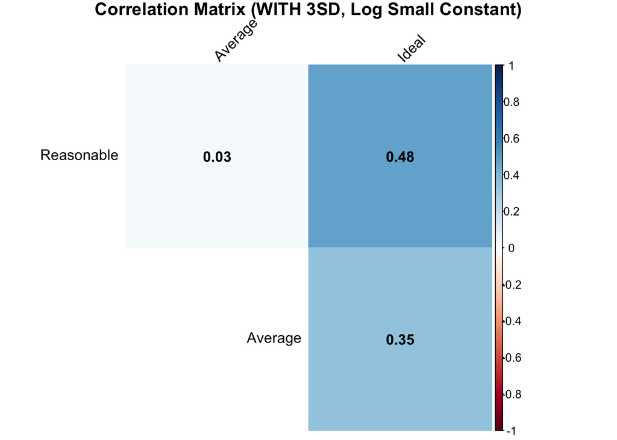

```r
ggsave("all_median_regression_plots_3sd_smallval.png", grid_plots_median_3sd_smallval, width = 14, height = 10, dpi = 300)

# Correlation matrix
cor_data_3sd_smallval <- dataforAICMedians_3sd_smallval[complete.cases(dataforAICMedians_3sd_smallval) & is.finite(rowSums(dataforAICMedians_3sd_smallval)),]
if(nrow(cor_data_3sd_smallval) > 1) {
 cor_matrix_3sd_smallval <- cor(cor_data_3sd_smallval, use = "complete.obs")
 corrplot(cor_matrix_3sd_smallval, method = "color", type = "upper", addCoef.col = "black", tl.col = "black", tl.srt = 45, diag = FALSE, title = "Correlation Matrix (WITH 3SD, Log Small Constant)", mar = c(0,0,1,0))
} else {
 cat("Not enough valid data points for correlation matrix (WITH 3SD, Log Small Constant).\n")
}
```

```r
# Coefficient tables
model1_coefs_3sd_smallval <- get_model_coefs(Model1Medians_3sd_smallval)
model2_coefs_3sd_smallval <- get_model_coefs(Model2Medians_3sd_smallval)
model3_coefs_3sd_smallval <- get_model_coefs(Model3Medians_3sd_smallval)
model1_coefs_3sd_smallval$p_value <- sapply(model1_coefs_3sd_smallval$p_value, format_pvalue)
model2_coefs_3sd_smallval$p_value <- sapply(model2_coefs_3sd_smallval$p_value, format_pvalue)
model3_coefs_3sd_smallval$p_value <- sapply(model3_coefs_3sd_smallval$p_value, format_pvalue)

kable(model1_coefs_3sd_smallval, caption = "Model 1 Coeffs (WITH 3SD, Log Small Const)") %>% kable_styling()
```

Model 1 Coeffs (WITH 3SD, Log Small Const)

|  | Term | Estimate | Std_Error | t_value | p_value |
| --- | --- | --- | --- | --- | --- |
| (Intercept) | (Intercept) | 0.4402684 | 1.2480721 | 0.3527588 | 0.727 |
| Average | Average | 0.0730147 | 0.3894403 | 0.1874862 | 0.853 |

```r
kable(model2_coefs_3sd_smallval, caption = "Model 2 Coeffs (WITH 3SD, Log Small Const)") %>% kable_styling()
```

Model 2 Coeffs (WITH 3SD, Log Small Const)

|  | Term | Estimate | Std_Error | t_value | p_value |
| --- | --- | --- | --- | --- | --- |
| (Intercept) | (Intercept) | 0.0051119 | 0.5985817 | 0.00854 | 0.993 |
| Ideal | Ideal | 0.5827017 | 0.1937527 | 3.00745 | 0.005 |

```r
kable(model3_coefs_3sd_smallval, caption = "Model 3 Coeffs (WITH 3SD, Log Small Const)") %>% kable_styling()
```

Model 3 Coeffs (WITH 3SD, Log Small Const)

|  | Term | Estimate | Std_Error | t_value | p_value |
| --- | --- | --- | --- | --- | --- |
| (Intercept) | (Intercept) | 0.8265861 | 1.1096899 | 0.7448803 | 0.462 |
| Average | Average | -0.3229615 | 0.3668089 | -0.8804627 | 0.386 |
| Ideal | Ideal | 0.6459338 | 0.2072968 | 3.1159849 | 0.004 |

```r
# Print model summaries
cat("\nModel Summaries (WITH 3SD, Log Small Constant):\n")
```

```
##
## Model Summaries (WITH 3SD, Log Small Constant):
```

```r
print(summary(Model1Medians_3sd_smallval))
```

```
##
## Call:
## lm(formula = Reasonable ~ Average, data = dataforAICMedians_3sd_smallval)
##
## Residuals:
##     Min      1Q  Median      3Q     Max
## -5.6004 -5.1630  0.7646  2.5093  6.8288
##
## Coefficients:
##             Estimate Std. Error t value Pr(>|t|)
## (Intercept)  0.44027    1.24807   0.353    0.727
## Average      0.07301    0.38944   0.187    0.853
##
## Residual standard error: 3.654 on 31 degrees of freedom
## Multiple R-squared:  0.001133,   Adjusted R-squared:  -0.03109
## F-statistic: 0.03515 on 1 and 31 DF,  p-value: 0.8525
```

```r
print(summary(Model2Medians_3sd_smallval))
```

```
##
## Call:
## lm(formula = Reasonable ~ Ideal, data = dataforAICMedians_3sd_smallval)
##
## Residuals:
##     Min      1Q  Median      3Q     Max
## -8.2315 -1.9268  0.8438  2.0528  3.7769
##
## Coefficients:
##             Estimate Std. Error t value Pr(>|t|)
## (Intercept) 0.005112   0.598582   0.009  0.99324
## Ideal       0.582702   0.193753   3.007  0.00519 **
## ---
## Signif. codes:  0 '***' 0.001 '**' 0.01 '*' 0.05 '.' 0.1 ' ' 1
##
## Residual standard error: 3.216 on 31 degrees of freedom
## Multiple R-squared:  0.2259, Adjusted R-squared:  0.2009
## F-statistic: 9.045 on 1 and 31 DF,  p-value: 0.00519
```

```r
print(summary(Model3Medians_3sd_smallval))
```

```
##
## Call:
## lm(formula = Reasonable ~ Average + Ideal, data = dataforAICMedians_3sd_smallval)
##
## Residuals:
##     Min      1Q  Median      3Q     Max
## -6.9912 -1.3587  0.4982  2.1684  4.5426
##
## Coefficients:
##             Estimate Std. Error t value Pr(>|t|)
## (Intercept)   0.8266     1.1097   0.745  0.46214
## Average      -0.3230     0.3668  -0.880  0.38561
## Ideal         0.6459     0.2073   3.116  0.00402 **
## ---
## Signif. codes:  0 '***' 0.001 '**' 0.01 '*' 0.05 '.' 0.1 ' ' 1
##
## Residual standard error: 3.228 on 30 degrees of freedom
## Multiple R-squared:  0.2454, Adjusted R-squared:  0.1951
## F-statistic: 4.877 on 2 and 30 DF,  p-value: 0.01466
```

#### 4b. (Plus one to all values): Plots and Reporting (WITH 3SD Removal)

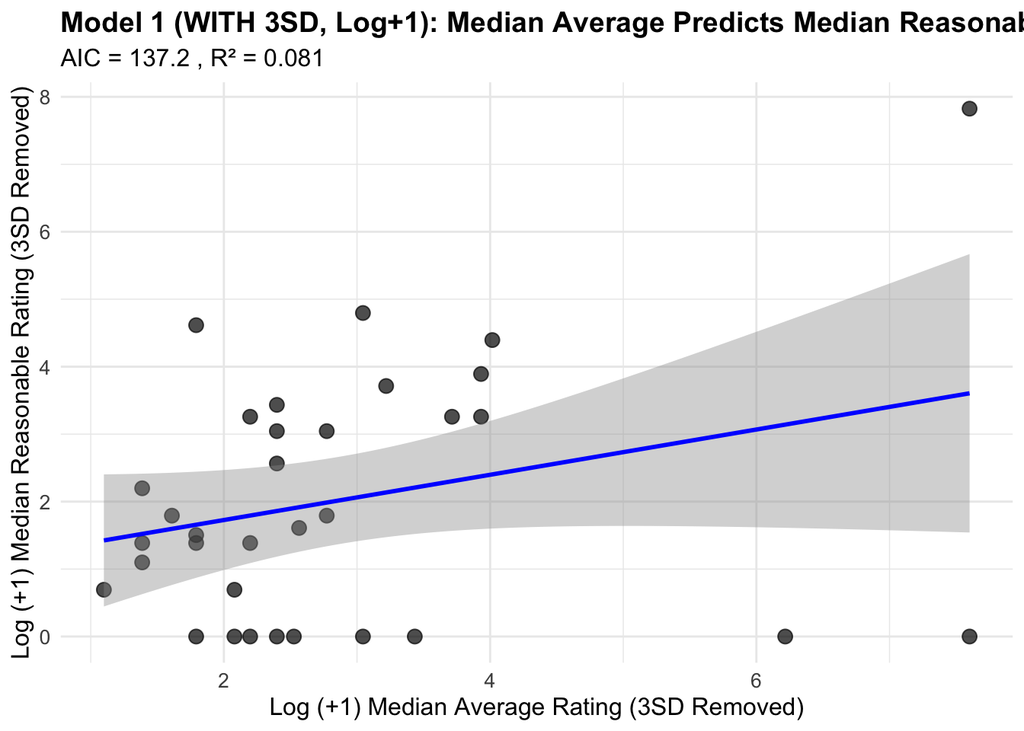

```r
# Average Median vs Reasonable Median
plot1_median_3sd_plusone <- ggplot(dataforAICMedians_3sd_plusone, aes(x = Average, y = Reasonable)) +
  geom_point(size = 3, alpha = 0.7) +
  geom_smooth(method = "lm", se = TRUE, color = "blue") +
  labs(title = "Model 1 (WITH 3SD, Log+1): Median Average Predicts Median Reasonable",
       subtitle = paste("AIC =", round(AIC1Medians_3sd_plusone, 2), ", R² =", round(r2_model1_median_3sd_plusone, 3)),
       x = "Log (+1) Median Average Rating (3SD Removed)",
       y = "Log (+1) Median Reasonable Rating (3SD Removed)") +
  theme_minimal() + # Add theme elements as before
  theme(
    plot.title = element_text(size = 14, face = "bold"),
    plot.subtitle = element_text(size = 12),
    axis.title = element_text(size = 12),
    axis.text = element_text(size = 10)
  )

# Ideal Median vs Reasonable Median
plot2_median_3sd_plusone <- ggplot(dataforAICMedians_3sd_plusone, aes(x = Ideal, y = Reasonable)) +
   geom_point(size = 3, alpha = 0.7) +
   geom_smooth(method = "lm", se = TRUE, color = "red") +
   labs(title = "Model 2 (WITH 3SD, Log+1): Median Ideal Predicts Median Reasonable",
        subtitle = paste("AIC =", round(AIC2Medians_3sd_plusone, 2), ", R² =", round(r2_model2_median_3sd_plusone, 3)),
        x = "Log (+1) Median Ideal Rating (3SD Removed)",
        y = "Log (+1) Median Reasonable Rating (3SD Removed)") +
  theme_minimal() + # Add theme elements
  theme(
    plot.title = element_text(size = 14, face = "bold"),
    plot.subtitle = element_text(size = 12),
    axis.title = element_text(size = 12),
    axis.text = element_text(size = 10)
  )

# Model 3 visualizations (effect of average, holding ideal constant)
new_data_median_3sd_plusone <- expand.grid(
  Average = seq(min(dataforAICMedians_3sd_plusone$Average, na.rm=TRUE), max(dataforAICMedians_3sd_plusone$Average, na.rm=TRUE), length.out = 100),
  Ideal = median(dataforAICMedians_3sd_plusone$Ideal, na.rm=TRUE)
)
new_data_median_3sd_plusone <- new_data_median_3sd_plusone[is.finite(new_data_median_3sd_plusone$Average) & is.finite(new_data_median_3sd_plusone$Ideal),]
if(nrow(new_data_median_3sd_plusone)>0){
    new_data_median_3sd_plusone$predicted_reasonable <- predict(Model3Medians_3sd_plusone, newdata = new_data_median_3sd_plusone)
} else {
    new_data_median_3sd_plusone <- data.frame(Average=numeric(), Ideal=numeric(), predicted_reasonable=numeric())
}
plot3_median_3sd_plusone <- ggplot(dataforAICMedians_3sd_plusone, aes(x = Average, y = Reasonable)) +
  geom_point(size = 3, alpha = 0.5) +
  geom_line(data = new_data_median_3sd_plusone, aes(y = predicted_reasonable), color = "blue", size = 1) +
  labs(title = "Model 3 (WITH 3SD, Log+1): Effect of Median Average",
       subtitle = paste("AIC =", round(AIC3Medians_3sd_plusone, 2), ", R² =", round(r2_model3_median_3sd_plusone, 3)),
       x = "Log (+1) Median Average Rating (3SD Removed)",
       y = "Log (+1) Median Reasonable Rating (3SD Removed)") +
  theme_minimal() + # Add theme elements
  theme(
    plot.title = element_text(size = 14, face = "bold"),
    plot.subtitle = element_text(size = 12),
    axis.title = element_text(size = 12),
    axis.text = element_text(size = 10)
  )

# Model 3 visualization (effect of ideal, holding average constant)
new_data2_median_3sd_plusone <- expand.grid(
  Average = median(dataforAICMedians_3sd_plusone$Average, na.rm=TRUE),
  Ideal = seq(min(dataforAICMedians_3sd_plusone$Ideal, na.rm=TRUE), max(dataforAICMedians_3sd_plusone$Ideal, na.rm=TRUE), length.out = 100)
)
new_data2_median_3sd_plusone <- new_data2_median_3sd_plusone[is.finite(new_data2_median_3sd_plusone$Average) & is.finite(new_data2_median_3sd_plusone$Ideal),]
if(nrow(new_data2_median_3sd_plusone)>0){
    new_data2_median_3sd_plusone$predicted_reasonable <- predict(Model3Medians_3sd_plusone, newdata = new_data2_median_3sd_plusone)
} else {
     new_data2_median_3sd_plusone <- data.frame(Average=numeric(), Ideal=numeric(), predicted_reasonable=numeric())
}
plot4_median_3sd_plusone <- ggplot(dataforAICMedians_3sd_plusone, aes(x = Ideal, y = Reasonable)) +
   geom_point(size = 3, alpha = 0.5) +
   geom_line(data = new_data2_median_3sd_plusone, aes(y = predicted_reasonable), color = "red", size = 1) +
   labs(title = "Model 3 (WITH 3SD, Log+1): Effect of Median Ideal",
        subtitle = paste("AIC =", round(AIC3Medians_3sd_plusone, 2), ", R² =", round(r2_model3_median_3sd_plusone, 3)),
        x = "Log (+1) Median Ideal Rating (3SD Removed)",
        y = "Log (+1) Median Reasonable Rating (3SD Removed)") +
  theme_minimal() + # Add theme elements
   theme(
    plot.title = element_text(size = 14, face = "bold"),
    plot.subtitle = element_text(size = 12),
    axis.title = element_text(size = 12),
    axis.text = element_text(size = 10)
  )


# Display plots
print(plot1_median_3sd_plusone)
```

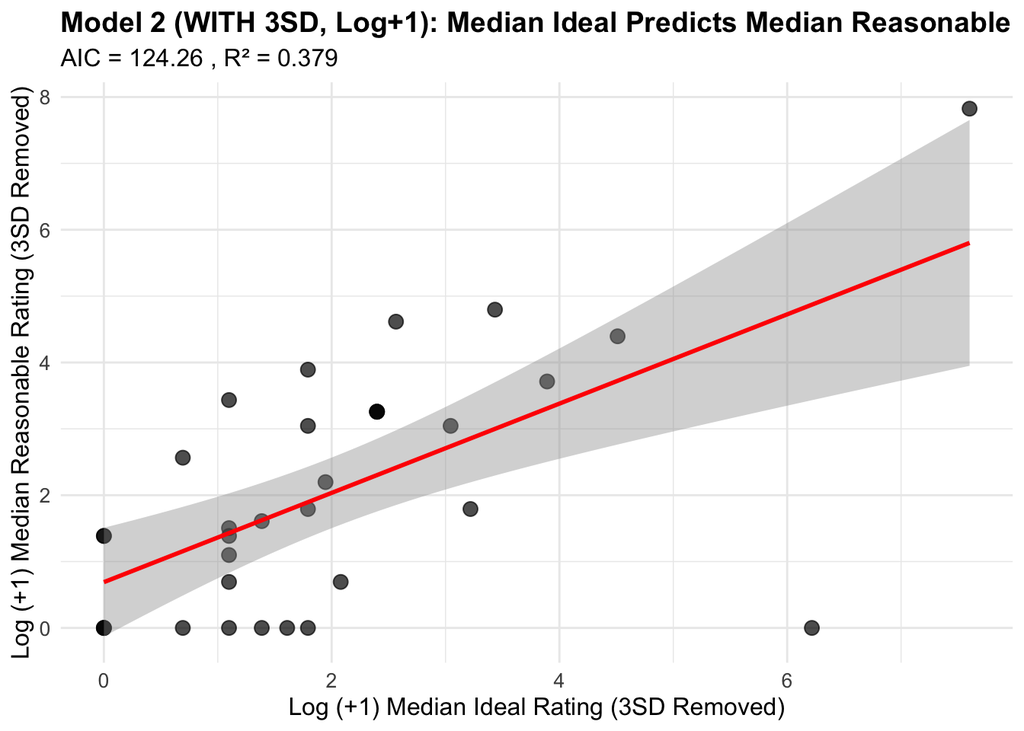

```r
print(plot2_median_3sd_plusone)
```

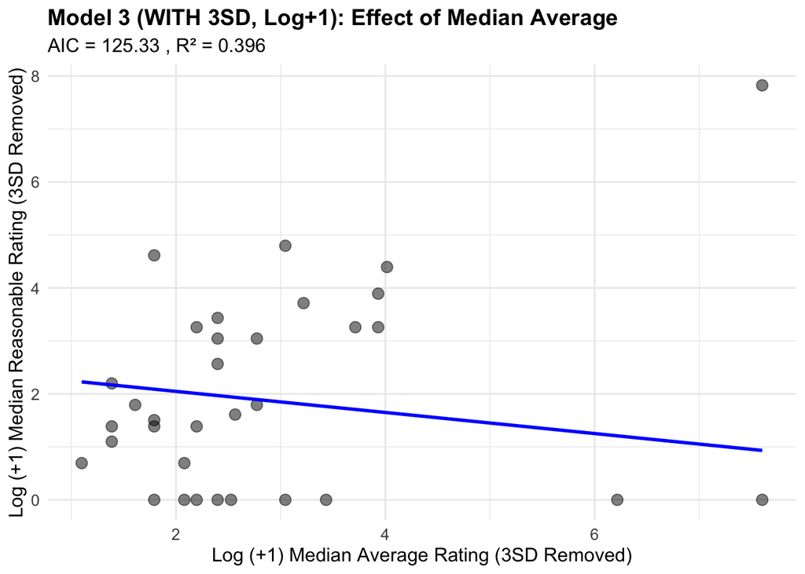

```r
print(plot3_median_3sd_plusone)
```

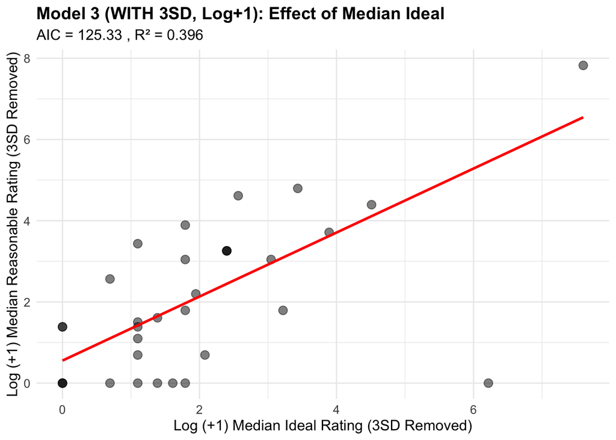

```r
print(plot4_median_3sd_plusone)
```

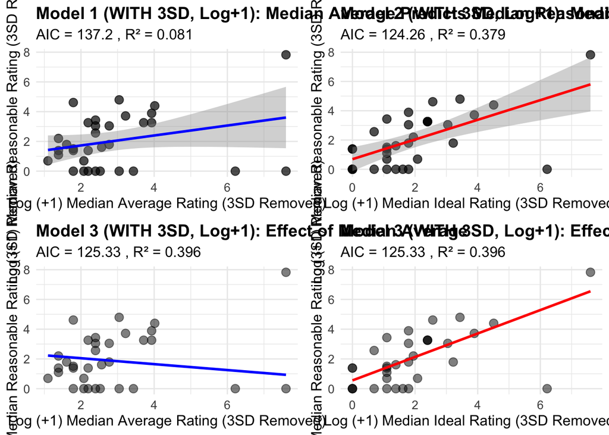

```r
# Save plots
ggsave("model1_median_avg_reas_3sd_plusone.png", plot1_median_3sd_plusone, width = 8, height = 6, dpi = 300)
ggsave("model2_median_ideal_reas_3sd_plusone.png", plot2_median_3sd_plusone, width = 8, height = 6, dpi = 300)
ggsave("model3_median_avg_eff_3sd_plusone.png", plot3_median_3sd_plusone, width = 8, height = 6, dpi = 300)
ggsave("model3_median_ideal_eff_3sd_plusone.png", plot4_median_3sd_plusone, width = 8, height = 6, dpi = 300)

# Combined plot layout
grid_plots_median_3sd_plusone <- grid.arrange(plot1_median_3sd_plusone, plot2_median_3sd_plusone, plot3_median_3sd_plusone, plot4_median_3sd_plusone, ncol = 2)
```

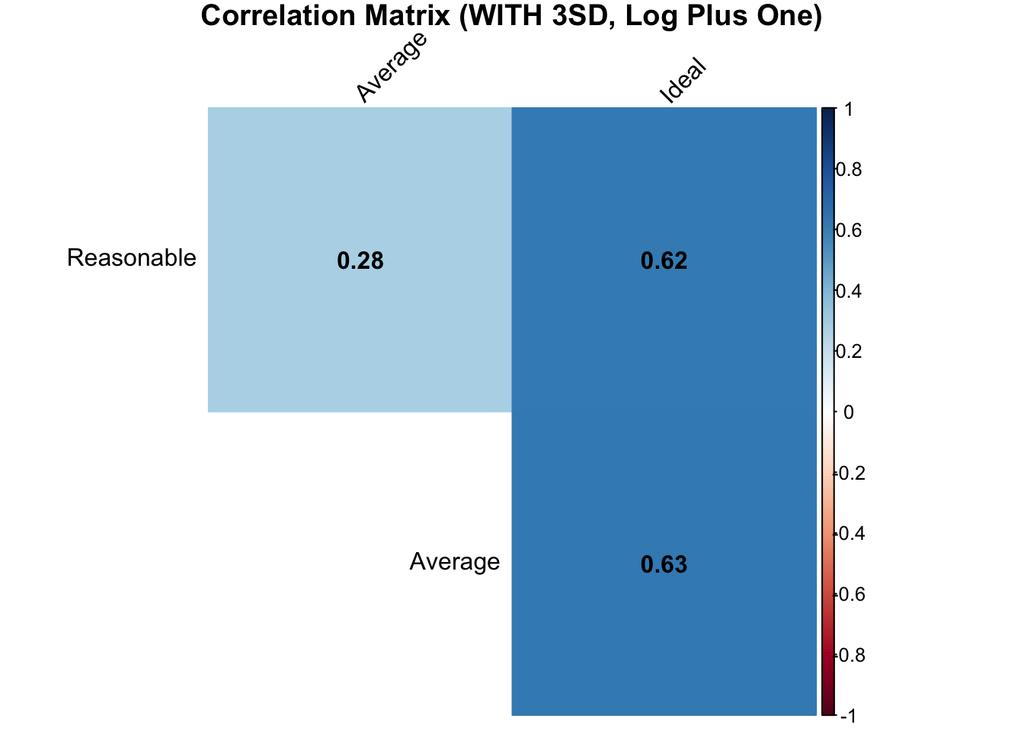

```r
ggsave("all_median_regression_plots_3sd_plusone.png", grid_plots_median_3sd_plusone, width = 14, height = 10, dpi = 300)

# Correlation matrix
cor_data_3sd_plusone <- dataforAICMedians_3sd_plusone[complete.cases(dataforAICMedians_3sd_plusone) & is.finite(rowSums(dataforAICMedians_3sd_plusone)),]
if(nrow(cor_data_3sd_plusone) > 1) {
 cor_matrix_3sd_plusone <- cor(cor_data_3sd_plusone, use = "complete.obs")
 corrplot(cor_matrix_3sd_plusone, method = "color", type = "upper", addCoef.col = "black", tl.col = "black", tl.srt = 45, diag = FALSE, title = "Correlation Matrix (WITH 3SD, Log Plus One)", mar = c(0,0,1,0))
} else {
 cat("Not enough valid data points for correlation matrix (WITH 3SD, Log Plus One).\n")
}
```

```r
# Coefficient tables
model1_coefs_3sd_plusone <- get_model_coefs(Model1Medians_3sd_plusone)
model2_coefs_3sd_plusone <- get_model_coefs(Model2Medians_3sd_plusone)
model3_coefs_3sd_plusone <- get_model_coefs(Model3Medians_3sd_plusone)
model1_coefs_3sd_plusone$p_value <- sapply(model1_coefs_3sd_plusone$p_value, format_pvalue)
model2_coefs_3sd_plusone$p_value <- sapply(model2_coefs_3sd_plusone$p_value, format_pvalue)
model3_coefs_3sd_plusone$p_value <- sapply(model3_coefs_3sd_plusone$p_value, format_pvalue)

kable(model1_coefs_3sd_plusone, caption = "Model 1 Coeffs (WITH 3SD, Log Plus One)") %>% kable_styling()
```

Model 1 Coeffs (WITH 3SD, Log Plus One)

|  | Term | Estimate | Std_Error | t_value | p_value |
| --- | --- | --- | --- | --- | --- |
| (Intercept) | (Intercept) | 1.0561431 | 0.6640895 | 1.590362 | 0.122 |
| Average | Average | 0.3353787 | 0.2031594 | 1.650816 | 0.109 |

```r
kable(model2_coefs_3sd_plusone, caption = "Model 2 Coeffs (WITH 3SD, Log Plus One)") %>% kable_styling()
```

Model 2 Coeffs (WITH 3SD, Log Plus One)

|  | Term | Estimate | Std_Error | t_value | p_value |
| --- | --- | --- | --- | --- | --- |
| (Intercept) | (Intercept) | 0.6899572 | 0.401816 | 1.717097 | 0.096 |
| Ideal | Ideal | 0.6725056 | 0.154655 | 4.348424 | < .001 |

```r
kable(model3_coefs_3sd_plusone, caption = "Model 3 Coeffs (WITH 3SD, Log Plus One)") %>% kable_styling()
```

Model 3 Coeffs (WITH 3SD, Log Plus One)

|  | Term | Estimate | Std_Error | t_value | p_value |
| --- | --- | --- | --- | --- | --- |
| (Intercept) | (Intercept) | 1.0327497 | 0.5472044 | 1.8873199 | 0.069 |
| Average | Average | -0.1990130 | 0.2150633 | -0.9253697 | 0.362 |
| Ideal | Ideal | 0.7882162 | 0.1991612 | 3.9576789 | < .001 |

```r
# Print model summaries
cat("\nModel Summaries (WITH 3SD, Log Plus One):\n")
```

```
##
## Model Summaries (WITH 3SD, Log Plus One):
```

```r
print(summary(Model1Medians_3sd_plusone))
```

```
##
## Call:
## lm(formula = Reasonable ~ Average, data = dataforAICMedians_3sd_plusone)
##
## Residuals:
##    Min     1Q Median     3Q    Max
## -3.606 -1.657 -0.153  1.184  4.219
##
## Coefficients:
##             Estimate Std. Error t value Pr(>|t|)
## (Intercept)   1.0561     0.6641   1.590    0.122
## Average       0.3354     0.2032   1.651    0.109
##
## Residual standard error: 1.822 on 31 degrees of freedom
## Multiple R-squared:  0.08081,    Adjusted R-squared:  0.05115
## F-statistic: 2.725 on 1 and 31 DF,  p-value: 0.1089
```

```r
print(summary(Model2Medians_3sd_plusone))
```

```
##
## Call:
## lm(formula = Reasonable ~ Ideal, data = dataforAICMedians_3sd_plusone)
##
## Residuals:
##     Min      1Q  Median      3Q     Max
## -4.8707 -0.7356  0.0753  0.9555  2.2002
##
## Coefficients:
##             Estimate Std. Error t value Pr(>|t|)
## (Intercept)   0.6900     0.4018   1.717 0.095938 .
## Ideal         0.6725     0.1547   4.348 0.000138 ***
## ---
## Signif. codes:  0 '***' 0.001 '**' 0.01 '*' 0.05 '.' 0.1 ' ' 1
##
## Residual standard error: 1.498 on 31 degrees of freedom
## Multiple R-squared:  0.3789, Adjusted R-squared:  0.3588
## F-statistic: 18.91 on 1 and 31 DF,  p-value: 0.0001375
```

```r
print(summary(Model3Medians_3sd_plusone))
```

```
##
## Call:
## lm(formula = Reasonable ~ Average + Ideal, data = dataforAICMedians_3sd_plusone)
##
## Residuals:
##     Min      1Q  Median      3Q     Max
## -4.4200 -0.9869 -0.0056  1.0743  2.3129
##
## Coefficients:
##             Estimate Std. Error t value Pr(>|t|)
## (Intercept)   1.0327     0.5472   1.887 0.068826 .
## Average      -0.1990     0.2151  -0.925 0.362158
## Ideal         0.7882     0.1992   3.958 0.000429 ***
## ---
## Signif. codes:  0 '***' 0.001 '**' 0.01 '*' 0.05 '.' 0.1 ' ' 1
##
## Residual standard error: 1.502 on 30 degrees of freedom
## Multiple R-squared:  0.3961, Adjusted R-squared:  0.3558
## F-statistic: 9.839 on 2 and 30 DF,  p-value: 0.0005181
```

# Analysis 4 [NO 3 SD Outlier Removal]: Overall results, intermediacy with median ratings

Step 1 and Step 2 have been completed in the earlier analysis.

#### Functions for Analysis 4

```r
# Function to check if reasonable is on the "ideal side" of average
# Equal median ratings are treated as being on the predicted side
is_ideal_side_median <- function(average, ideal, reasonable) {
  if (any(is.na(c(average, ideal, reasonable)))) {
    return(NA)
  }
  # Check if distance to ideal is less than or equal to distance to average
  ifelse(abs(reasonable - ideal) <= abs(reasonable - average), 1, 0)
}

# Function to check if reasonable is on the "average side" of ideal
# Equal median ratings are treated as being on the predicted side
is_average_side_median <- function(average, ideal, reasonable) {
  if (any(is.na(c(average, ideal, reasonable)))) {
      return(NA)
  }
  # Check if distance to average is less than or equal to distance to ideal
  ifelse(abs(reasonable - average) <= abs(reasonable - ideal), 1, 0)
}

# Function to check if reasonable falls between average and ideal (inclusive)
# Handles cases where average == ideal
is_both_sides_median <- function(average, ideal, reasonable) {
  if (any(is.na(c(average, ideal, reasonable)))) {
      return(NA)
  }
  # Check if reasonable is numerically between average and ideal, inclusive
  # This works regardless of whether average > ideal or ideal > average
  ifelse((reasonable >= min(average, ideal)) & (reasonable <= max(average, ideal)), 1, 0)
}
```

#### Steps 3, 4, 5: Intermediacy Calculations (NO 3SD Removal)

```r
# Uses the medians calculated WITHOUT 3SD removal
# column_medians_average_no3sd, column_medians_ideal_no3sd, column_medians_reasonable_no3sd

# --- Ideal Side ---
ideal_side_vector_median_no3sd <- mapply(is_ideal_side_median, column_medians_average_no3sd, column_medians_ideal_no3sd, column_medians_reasonable_no3sd)
count_ideal_side_median_no3sd <- sum(ideal_side_vector_median_no3sd, na.rm = TRUE)
valid_questions_ideal_no3sd <- sum(!is.na(ideal_side_vector_median_no3sd))
if (valid_questions_ideal_no3sd > 0) {
  binomial_result_ideal_median_no3sd <- binom.test(count_ideal_side_median_no3sd, valid_questions_ideal_no3sd, p = 0.5, alternative = "greater")
  p_val_ideal_no3sd <- binomial_result_ideal_median_no3sd$p.value
} else { p_val_ideal_no3sd <- NA }
ideal_side_summary_median_no3sd <- data.frame(Count=count_ideal_side_median_no3sd, N=valid_questions_ideal_no3sd, Prop=ifelse(valid_questions_ideal_no3sd > 0, count_ideal_side_median_no3sd/valid_questions_ideal_no3sd, NA), p=p_val_ideal_no3sd)
kable(ideal_side_summary_median_no3sd, caption="Binomial Test (NO 3SD): Ideal Side") %>% kable_styling(bootstrap_options = c("striped", "hover", "condensed"), full_width = F)
```

Binomial Test (NO 3SD): Ideal Side

| Count | N | Prop | p |
| --- | --- | --- | --- |
| 25 | 33 | 0.7575758 | 0.0022757 |

```r
# --- Average Side ---
average_side_vector_median_no3sd <- mapply(is_average_side_median, column_medians_average_no3sd, column_medians_ideal_no3sd, column_medians_reasonable_no3sd)
count_average_side_median_no3sd <- sum(average_side_vector_median_no3sd, na.rm = TRUE)
valid_questions_avg_no3sd <- sum(!is.na(average_side_vector_median_no3sd))
if (valid_questions_avg_no3sd > 0) {
  binomial_result_avg_side_median_no3sd <- binom.test(count_average_side_median_no3sd, valid_questions_avg_no3sd, p = 0.5, alternative = "greater")
  p_val_avg_no3sd <- binomial_result_avg_side_median_no3sd$p.value
} else { p_val_avg_no3sd <- NA }
average_side_summary_median_no3sd <- data.frame(Count=count_average_side_median_no3sd, N=valid_questions_avg_no3sd, Prop=ifelse(valid_questions_avg_no3sd > 0, count_average_side_median_no3sd/valid_questions_avg_no3sd, NA), p=p_val_avg_no3sd)
kable(average_side_summary_median_no3sd, caption="Binomial Test (NO 3SD): Average Side") %>% kable_styling(bootstrap_options = c("striped", "hover", "condensed"), full_width = F)
```

Binomial Test (NO 3SD): Average Side

| Count | N | Prop | p |
| --- | --- | --- | --- |
| 12 | 33 | 0.3636364 | 0.9599283 |

```r
# --- Both Sides (Between) ---
both_sides_vector_median_no3sd <- mapply(is_both_sides_median, column_medians_average_no3sd, column_medians_ideal_no3sd, column_medians_reasonable_no3sd)
count_both_sides_median_no3sd <- sum(both_sides_vector_median_no3sd, na.rm = TRUE)
valid_questions_both_no3sd <- sum(!is.na(both_sides_vector_median_no3sd))
if (valid_questions_both_no3sd > 0) {
  binomial_result_both_sides_median_no3sd <- binom.test(count_both_sides_median_no3sd, valid_questions_both_no3sd, p = 1/3, alternative = "two.sided")
  p_val_both_no3sd <- binomial_result_both_sides_median_no3sd$p.value
} else { p_val_both_no3sd <- NA }
both_sides_summary_median_no3sd <- data.frame(Count=count_both_sides_median_no3sd, N=valid_questions_both_no3sd, Prop=ifelse(valid_questions_both_no3sd > 0, count_both_sides_median_no3sd/valid_questions_both_no3sd, NA), Expected=1/3, p=p_val_both_no3sd)
kable(both_sides_summary_median_no3sd, caption="Binomial Test (NO 3SD): Between Avg/Ideal") %>% kable_styling(bootstrap_options = c("striped", "hover", "condensed"), full_width = F)
```

Binomial Test (NO 3SD): Between Avg/Ideal

| Count | N | Prop | Expected | p |
| --- | --- | --- | --- | --- |
| 16 | 33 | 0.4848485 | 0.3333333 | 0.0944303 |

#### 6. Plots and Reporting (Intermediacy - Median Analysis, NO 3SD Removed)

```r
# Use the vectors/counts calculated just above (e.g., _no3sd suffix)
# Use the raw medians column_medians..._no3sd

# Create a table showing the results for each question
question_position_summary_median_no3sd <- data.frame(
  Question = names(column_medians_average_no3sd),
  Average_Value = column_medians_average_no3sd,
  Ideal_Value = column_medians_ideal_no3sd,
  Reasonable_Value = column_medians_reasonable_no3sd,
  On_Ideal_Side = ideal_side_vector_median_no3sd,
  On_Average_Side = average_side_vector_median_no3sd,
  Between_Average_And_Ideal = both_sides_vector_median_no3sd
)
# Handle NAs and Categorize (same logic as before)
question_position_summary_median_no3sd <- question_position_summary_median_no3sd %>%
  mutate(
    On_Ideal_Side = ifelse(is.na(On_Ideal_Side), 0, On_Ideal_Side),
    On_Average_Side = ifelse(is.na(On_Average_Side), 0, On_Average_Side),
    Between_Average_And_Ideal = ifelse(is.na(Between_Average_And_Ideal), 0, Between_Average_And_Ideal)
  )
question_position_summary_median_no3sd$Position <- "Other/NA"
question_position_summary_median_no3sd$Position[question_position_summary_median_no3sd$Between_Average_And_Ideal == 1] <- "Between Average and Ideal"
question_position_summary_median_no3sd$Position[question_position_summary_median_no3sd$Between_Average_And_Ideal == 0 & question_position_summary_median_no3sd$On_Ideal_Side == 1 & question_position_summary_median_no3sd$On_Average_Side == 0] <- "Beyond Ideal"
question_position_summary_median_no3sd$Position[question_position_summary_median_no3sd$Between_Average_And_Ideal == 0 & question_position_summary_median_no3sd$On_Average_Side == 1 & question_position_summary_median_no3sd$On_Ideal_Side == 0] <- "Beyond Average"
question_position_summary_median_no3sd$Position[
    !is.na(question_position_summary_median_no3sd$Average_Value) &
    !is.na(question_position_summary_median_no3sd$Ideal_Value) &
    question_position_summary_median_no3sd$Average_Value == question_position_summary_median_no3sd$Ideal_Value] <- "Average = Ideal"

# Display the question position summary
kable(question_position_summary_median_no3sd[, c("Question", "Average_Value", "Ideal_Value", "Reasonable_Value", "Position")],
      caption = "Position of Median Reasonable Rating (NO 3SD Removal) Relative to Average and Ideal") %>%
  kable_styling(bootstrap_options = c("striped", "hover", "condensed"), full_width = F)
```

Position of Median Reasonable Rating (NO 3SD Removal) Relative to Average and Ideal

|  | Question | Average_Value | Ideal_Value | Reasonable_Value | Position |
| --- | --- | --- | --- | --- | --- |
| q1 | q1 | 3.0 | 2.0 | 2 | Between Average and Ideal |
| q2 | q2 | 7.0 | 2.0 | 0 | Beyond Ideal |
| q3 | q3 | 3.0 | 6.0 | 8 | Beyond Ideal |
| q4 | q4 | 2000.0 | 2000.0 | 2500 | Average = Ideal |
| q5 | q5 | 20.0 | 30.0 | 120 | Beyond Ideal |
| q6 | q6 | 10.0 | 1.0 | 0 | Beyond Ideal |
| q7 | q7 | 15.0 | 5.0 | 20 | Beyond Average |
| q8 | q8 | 5.0 | 12.0 | 100 | Beyond Ideal |
| q9 | q9 | 5.0 | 3.0 | 0 | Beyond Ideal |
| q10 | q10 | 5.0 | 0.0 | 3 | Between Average and Ideal |
| q11 | q11 | 500.0 | 0.0 | 0 | Between Average and Ideal |
| q12 | q12 | 30.0 | 1.0 | 0 | Beyond Ideal |
| q13 | q13 | 40.0 | 10.0 | 25 | Between Average and Ideal |
| q14 | q14 | 10.0 | 2.0 | 30 | Beyond Average |
| q15 | q15 | 9.0 | 10.0 | 25 | Beyond Ideal |
| q16 | q16 | 5.0 | 5.0 | 5 | Average = Ideal |
| q17 | q17 | 3.0 | 0.0 | 3 | Between Average and Ideal |
| q18 | q18 | 15.0 | 2.0 | 12 | Between Average and Ideal |
| q20 | q20 | 20.0 | 0.0 | 0 | Between Average and Ideal |
| q21 | q21 | 8.0 | 5.0 | 0 | Beyond Ideal |
| q22 | q22 | 10.0 | 7.0 | 1 | Beyond Ideal |
| q23 | q23 | 2.0 | 3.0 | 1 | Beyond Average |
| q24 | q24 | 16.0 | 24.0 | 5 | Beyond Average |
| q25 | q25 | 2000.0 | 500.0 | 0 | Beyond Ideal |
| q26 | q26 | 8.0 | 2.0 | 3 | Between Average and Ideal |
| q27 | q27 | 12.0 | 5.0 | 0 | Beyond Ideal |
| q28 | q28 | 10.0 | 20.0 | 20 | Between Average and Ideal |
| q29 | q29 | 55.0 | 90.0 | 80 | Between Average and Ideal |
| q30 | q30 | 12.0 | 4.0 | 4 | Between Average and Ideal |
| q31 | q31 | 50.0 | 13.0 | 25 | Between Average and Ideal |
| q32 | q32 | 24.0 | 48.0 | 40 | Between Average and Ideal |
| q33 | q33 | 5.5 | 2.5 | 4 | Between Average and Ideal |
| q34 | q34 | 50.0 | 10.0 | 50 | Between Average and Ideal |

```r
# Count the number of questions in each position category
position_counts_median_no3sd <- table(question_position_summary_median_no3sd$Position)
position_summary_median_no3sd <- data.frame(Position = names(position_counts_median_no3sd), Count = as.numeric(position_counts_median_no3sd))
total_categorized_no3sd <- sum(position_summary_median_no3sd$Count)
position_summary_median_no3sd$Percentage <- ifelse(total_categorized_no3sd > 0, (position_summary_median_no3sd$Count / total_categorized_no3sd) * 100, 0)
position_summary_median_no3sd$Percentage <- round(position_summary_median_no3sd$Percentage, 1)

# Display the position count summary
kable(position_summary_median_no3sd, caption = "Distribution of Position Categories (Median Values, NO 3SD Removal)") %>%
  kable_styling(bootstrap_options = c("striped", "hover", "condensed"), full_width = F)
```

Distribution of Position Categories (Median Values, NO 3SD Removal)

| Position | Count | Percentage |
| --- | --- | --- |
| Average = Ideal | 2 | 6.1 |
| Between Average and Ideal | 15 | 6.1 |
| Beyond Average | 4 | 6.1 |
| Beyond Ideal | 12 | 6.1 |

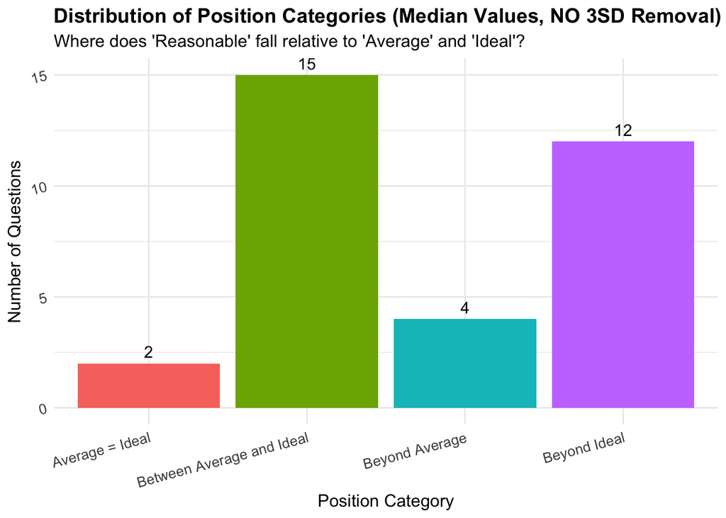

```r
# Create distribution plot
position_distribution_plot_median_no3sd <- ggplot(position_summary_median_no3sd, aes(x = Position, y = Count, fill = Position)) +
  geom_bar(stat = "identity") +
  geom_text(aes(label = paste0(Count)), vjust = -0.5, size = 4) +
  labs(title = "Distribution of Position Categories (Median Values, NO 3SD Removal)",
       subtitle = "Where does 'Reasonable' fall relative to 'Average' and 'Ideal'?",
       x = "Position Category", y = "Number of Questions") +
  theme_minimal() + theme(plot.title = element_text(size = 14, face = "bold"), plot.subtitle = element_text(size = 12), axis.title = element_text(size = 12), axis.text = element_text(size = 10, angle = 15, hjust = 1), legend.position = "none")
print(position_distribution_plot_median_no3sd)
```

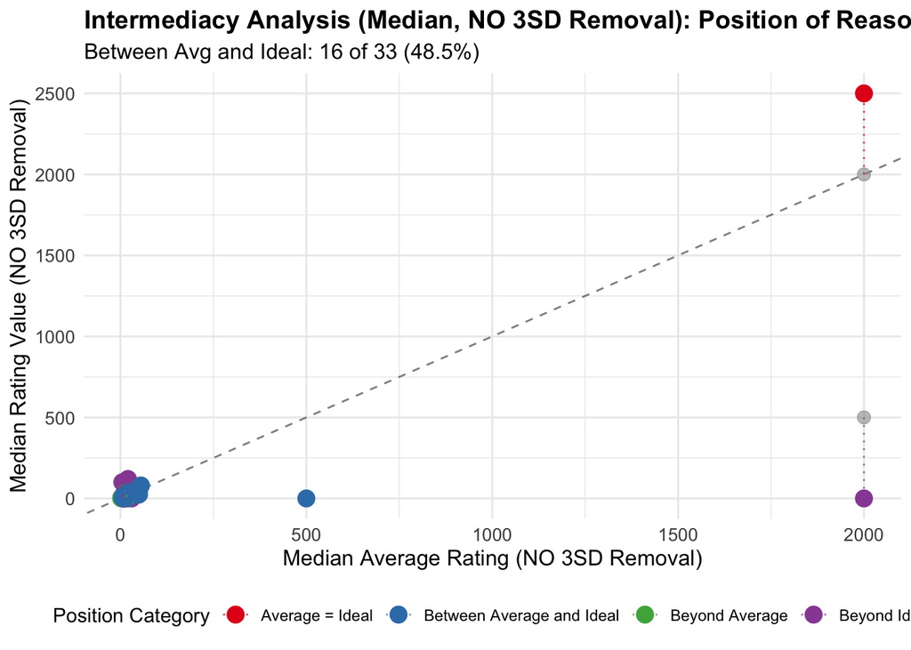

```r
ggsave("position_distribution_median_no3sd_removed.png", position_distribution_plot_median_no3sd, width = 10, height = 7, dpi = 300)

# Create scatterplot
plot_data_intermediacy_no3sd <- question_position_summary_median_no3sd %>% filter(!is.na(Average_Value) & !is.na(Ideal_Value) & !is.na(Reasonable_Value))
intermediacy_plot_median_no3sd <- ggplot(plot_data_intermediacy_no3sd, aes(x = Average_Value, y = Ideal_Value)) +
  geom_abline(intercept = 0, slope = 1, linetype = "dashed", alpha = 0.5) +
  geom_point(color = "gray60", size = 3, alpha = 0.6) +
  geom_point(aes(x = Average_Value, y = Reasonable_Value, color = Position), size = 4) +
  geom_segment(aes(x = Average_Value, xend = Average_Value, y = Ideal_Value, yend = Reasonable_Value, color = Position), linetype = "dotted", size = 0.5, alpha = 0.7) +
  scale_color_brewer(palette = "Set1") +
  labs(title = "Intermediacy Analysis (Median, NO 3SD Removal): Position of Reasonable",
       subtitle = paste0("Between Avg and Ideal: ", count_both_sides_median_no3sd, " of ", valid_questions_both_no3sd, " (", scales::percent(count_both_sides_median_no3sd/valid_questions_both_no3sd, accuracy=0.1), ")"),
       x = "Median Average Rating (NO 3SD Removal)", y = "Median Rating Value (NO 3SD Removal)", color = "Position Category") +
  theme_minimal() + theme(plot.title = element_text(size = 14, face = "bold"), plot.subtitle = element_text(size = 12), axis.title = element_text(size = 12), axis.text = element_text(size = 10), legend.position = "bottom")
print(intermediacy_plot_median_no3sd)
```

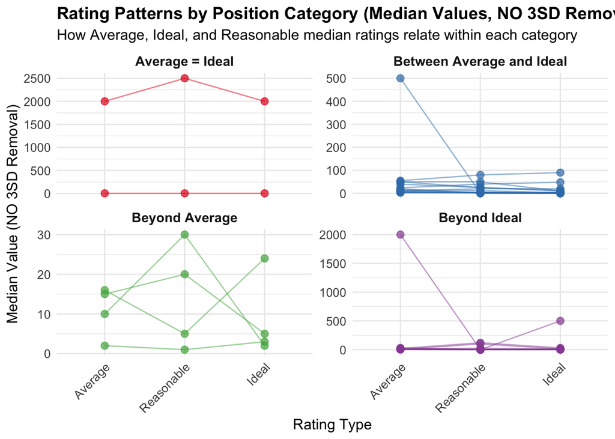

```r
ggsave("intermediacy_analysis_median_no3sd_removed.png", intermediacy_plot_median_no3sd, width = 10, height = 8, dpi = 300)

# Create rating patterns plot
ratings_long_median_no3sd <- question_position_summary_median_no3sd %>%
  select(Question, Average_Value, Ideal_Value, Reasonable_Value, Position) %>%
  pivot_longer(cols = c(Average_Value, Ideal_Value, Reasonable_Value), names_to = "Rating_Type", values_to = "Value") %>%
  mutate(Rating_Type = factor(gsub("_Value", "", Rating_Type), levels = c("Average", "Reasonable", "Ideal"))) %>%
  filter(!is.na(Value))
rating_patterns_plot_median_no3sd <- ggplot(ratings_long_median_no3sd, aes(x = Rating_Type, y = Value, group = Question, color = Position)) +
  geom_line(alpha = 0.5) + geom_point(size = 2.5, alpha=0.7) + facet_wrap(~ Position, scales = "free_y") +
  scale_color_brewer(palette = "Set1") +
  labs(title = "Rating Patterns by Position Category (Median Values, NO 3SD Removal)",
       subtitle = "How Average, Ideal, and Reasonable median ratings relate within each category",
       x = "Rating Type", y = "Median Value (NO 3SD Removal)") +
  theme_minimal() + theme(plot.title = element_text(size = 14, face = "bold"), plot.subtitle = element_text(size = 12), axis.title = element_text(size = 12), axis.text.x = element_text(size = 10, angle = 45, hjust = 1), axis.text.y = element_text(size = 10), strip.text = element_text(size=11, face="bold"), legend.position = "none")
print(rating_patterns_plot_median_no3sd)
```

```r
ggsave("rating_patterns_by_position_median_no3sd_removed.png", rating_patterns_plot_median_no3sd, width = 12, height = 8, dpi = 300)

# Store results
analysis_4_results_no3sd <- list(
  ideal_side = list(vector=ideal_side_vector_median_no3sd, count=count_ideal_side_median_no3sd, valid_n=valid_questions_ideal_no3sd, summary=ideal_side_summary_median_no3sd),
  average_side = list(vector=average_side_vector_median_no3sd, count=count_average_side_median_no3sd, valid_n=valid_questions_avg_no3sd, summary=average_side_summary_median_no3sd),
  both_sides = list(vector=both_sides_vector_median_no3sd, count=count_both_sides_median_no3sd, valid_n=valid_questions_both_no3sd, summary=both_sides_summary_median_no3sd),
  question_position = question_position_summary_median_no3sd,
  position_summary = position_summary_median_no3sd
)
```

# Analysis 4 [WITH 3 SD Outlier Removal]: Overall results, intermediacy with median ratings

Step 1 and Step 2 have been completed in the earlier analysis.

#### Functions for Analysis 4

```r
# Function to check if reasonable is on the "ideal side" of average
# Equal median ratings are treated as being on the predicted side
is_ideal_side_median <- function(average, ideal, reasonable) {
  if (any(is.na(c(average, ideal, reasonable)))) {
    return(NA)
  }
  # Check if distance to ideal is less than or equal to distance to average
  ifelse(abs(reasonable - ideal) <= abs(reasonable - average), 1, 0)
}

# Function to check if reasonable is on the "average side" of ideal
# Equal median ratings are treated as being on the predicted side
is_average_side_median <- function(average, ideal, reasonable) {
  if (any(is.na(c(average, ideal, reasonable)))) {
      return(NA)
  }
  # Check if distance to average is less than or equal to distance to ideal
  ifelse(abs(reasonable - average) <= abs(reasonable - ideal), 1, 0)
}

# Function to check if reasonable falls between average and ideal (inclusive)
# Handles cases where average == ideal
is_both_sides_median <- function(average, ideal, reasonable) {
  if (any(is.na(c(average, ideal, reasonable)))) {
      return(NA)
  }
  # Check if reasonable is numerically between average and ideal, inclusive
  # This works regardless of whether average > ideal or ideal > average
  ifelse((reasonable >= min(average, ideal)) & (reasonable <= max(average, ideal)), 1, 0)
}
```

#### Steps 3, 4, 5: Intermediacy Calculations (WITH 3SD Removal)

```r
# Use the medians calculated WITH 3SD removal
# column_medians_average_3sd, column_medians_ideal_3sd, column_medians_reasonable_3sd

# --- Ideal Side ---
ideal_side_vector_median_3sd <- mapply(is_ideal_side_median, column_medians_average_3sd, column_medians_ideal_3sd, column_medians_reasonable_3sd)
count_ideal_side_median_3sd <- sum(ideal_side_vector_median_3sd, na.rm = TRUE)
valid_questions_ideal_3sd <- sum(!is.na(ideal_side_vector_median_3sd))
if (valid_questions_ideal_3sd > 0) {
  binomial_result_ideal_median_3sd <- binom.test(count_ideal_side_median_3sd, valid_questions_ideal_3sd, p = 0.5, alternative = "greater")
  p_val_ideal_3sd <- binomial_result_ideal_median_3sd$p.value
} else { p_val_ideal_3sd <- NA }
ideal_side_summary_median_3sd <- data.frame(Count=count_ideal_side_median_3sd, N=valid_questions_ideal_3sd, Prop=ifelse(valid_questions_ideal_3sd > 0, count_ideal_side_median_3sd/valid_questions_ideal_3sd, NA), p=p_val_ideal_3sd)
kable(ideal_side_summary_median_3sd, caption="Binomial Test (WITH 3SD): Ideal Side") %>% kable_styling(bootstrap_options = c("striped", "hover", "condensed"), full_width = F)
```

Binomial Test (WITH 3SD): Ideal Side

| Count | N | Prop | p |
| --- | --- | --- | --- |
| 26 | 33 | 0.7878788 | 0.0006594 |

```r
# --- Average Side ---
average_side_vector_median_3sd <- mapply(is_average_side_median, column_medians_average_3sd, column_medians_ideal_3sd, column_medians_reasonable_3sd)
count_average_side_median_3sd <- sum(average_side_vector_median_3sd, na.rm = TRUE)
valid_questions_avg_3sd <- sum(!is.na(average_side_vector_median_3sd))
if (valid_questions_avg_3sd > 0) {
  binomial_result_avg_side_median_3sd <- binom.test(count_average_side_median_3sd, valid_questions_avg_3sd, p = 0.5, alternative = "greater")
  p_val_avg_3sd <- binomial_result_avg_side_median_3sd$p.value
} else { p_val_avg_3sd <- NA }
average_side_summary_median_3sd <- data.frame(Count=count_average_side_median_3sd, N=valid_questions_avg_3sd, Prop=ifelse(valid_questions_avg_3sd > 0, count_average_side_median_3sd/valid_questions_avg_3sd, NA), p=p_val_avg_3sd)
kable(average_side_summary_median_3sd, caption="Binomial Test (WITH 3SD): Average Side") %>% kable_styling(bootstrap_options = c("striped", "hover", "condensed"), full_width = F)
```

Binomial Test (WITH 3SD): Average Side

| Count | N | Prop | p |
| --- | --- | --- | --- |
| 12 | 33 | 0.3636364 | 0.9599283 |

```r
# --- Both Sides (Between) ---
both_sides_vector_median_3sd <- mapply(is_both_sides_median, column_medians_average_3sd, column_medians_ideal_3sd, column_medians_reasonable_3sd)
count_both_sides_median_3sd <- sum(both_sides_vector_median_3sd, na.rm = TRUE)
valid_questions_both_3sd <- sum(!is.na(both_sides_vector_median_3sd))
if (valid_questions_both_3sd > 0) {
  binomial_result_both_sides_median_3sd <- binom.test(count_both_sides_median_3sd, valid_questions_both_3sd, p = 1/3, alternative = "two.sided")
  p_val_both_3sd <- binomial_result_both_sides_median_3sd$p.value
} else { p_val_both_3sd <- NA }
both_sides_summary_median_3sd <- data.frame(Count=count_both_sides_median_3sd, N=valid_questions_both_3sd, Prop=ifelse(valid_questions_both_3sd > 0, count_both_sides_median_3sd/valid_questions_both_3sd, NA), Expected=1/3, p=p_val_both_3sd)
kable(both_sides_summary_median_3sd, caption="Binomial Test (WITH 3SD): Between Avg/Ideal") %>% kable_styling(bootstrap_options = c("striped", "hover", "condensed"), full_width = F)
```

Binomial Test (WITH 3SD): Between Avg/Ideal

| Count | N | Prop | Expected | p |
| --- | --- | --- | --- | --- |
| 16 | 33 | 0.4848485 | 0.3333333 | 0.0944303 |

#### 6. Plots and Reporting (Intermediacy - Median Analysis, WITH 3SD Removed)

```r
# Uses the vectors/counts calculated just above (e.g., _3sd suffix)
# Uses the raw medians column_medians..._3sd

# Create a table showing the results for each question
question_position_summary_median_3sd <- data.frame(
  Question = names(column_medians_average_3sd),
  Average_Value = column_medians_average_3sd,
  Ideal_Value = column_medians_ideal_3sd,
  Reasonable_Value = column_medians_reasonable_3sd,
  On_Ideal_Side = ideal_side_vector_median_3sd,
  On_Average_Side = average_side_vector_median_3sd,
  Between_Average_And_Ideal = both_sides_vector_median_3sd
)
# Handle NAs and Categorize (same logic as before)
question_position_summary_median_3sd <- question_position_summary_median_3sd %>%
  mutate(
    On_Ideal_Side = ifelse(is.na(On_Ideal_Side), 0, On_Ideal_Side),
    On_Average_Side = ifelse(is.na(On_Average_Side), 0, On_Average_Side),
    Between_Average_And_Ideal = ifelse(is.na(Between_Average_And_Ideal), 0, Between_Average_And_Ideal)
  )
question_position_summary_median_3sd$Position <- "Other/NA"
question_position_summary_median_3sd$Position[question_position_summary_median_3sd$Between_Average_And_Ideal == 1] <- "Between Average and Ideal"
question_position_summary_median_3sd$Position[question_position_summary_median_3sd$Between_Average_And_Ideal == 0 & question_position_summary_median_3sd$On_Ideal_Side == 1 & question_position_summary_median_3sd$On_Average_Side == 0] <- "Beyond Ideal"
question_position_summary_median_3sd$Position[question_position_summary_median_3sd$Between_Average_And_Ideal == 0 & question_position_summary_median_3sd$On_Average_Side == 1 & question_position_summary_median_3sd$On_Ideal_Side == 0] <- "Beyond Average"
question_position_summary_median_3sd$Position[
    !is.na(question_position_summary_median_3sd$Average_Value) &
    !is.na(question_position_summary_median_3sd$Ideal_Value) &
    question_position_summary_median_3sd$Average_Value == question_position_summary_median_3sd$Ideal_Value] <- "Average = Ideal"

# Display the question position summary
kable(question_position_summary_median_3sd[, c("Question", "Average_Value", "Ideal_Value", "Reasonable_Value", "Position")],
      caption = "Position of Median Reasonable Rating (WITH 3SD Removal) Relative to Average and Ideal") %>%
  kable_styling(bootstrap_options = c("striped", "hover", "condensed"), full_width = F)
```

Position of Median Reasonable Rating (WITH 3SD Removal) Relative to Average and Ideal

|  | Question | Average_Value | Ideal_Value | Reasonable_Value | Position |
| --- | --- | --- | --- | --- | --- |
| q1 | q1 | 3.0 | 2 | 2.0 | Between Average and Ideal |
| q2 | q2 | 7.0 | 2 | 0.0 | Beyond Ideal |
| q3 | q3 | 3.0 | 6 | 8.0 | Beyond Ideal |
| q4 | q4 | 2000.0 | 2000 | 2500.0 | Average = Ideal |
| q5 | q5 | 20.0 | 30 | 120.0 | Beyond Ideal |
| q6 | q6 | 10.0 | 1 | 0.0 | Beyond Ideal |
| q7 | q7 | 15.0 | 5 | 20.0 | Beyond Average |
| q8 | q8 | 5.0 | 12 | 100.0 | Beyond Ideal |
| q9 | q9 | 5.0 | 3 | 0.0 | Beyond Ideal |
| q10 | q10 | 5.0 | 0 | 3.0 | Between Average and Ideal |
| q11 | q11 | 500.0 | 0 | 0.0 | Between Average and Ideal |
| q12 | q12 | 30.0 | 0 | 0.0 | Between Average and Ideal |
| q13 | q13 | 40.0 | 10 | 25.0 | Between Average and Ideal |
| q14 | q14 | 10.0 | 2 | 30.0 | Beyond Average |
| q15 | q15 | 8.0 | 10 | 25.0 | Beyond Ideal |
| q16 | q16 | 4.0 | 5 | 5.0 | Between Average and Ideal |
| q17 | q17 | 3.0 | 0 | 3.0 | Between Average and Ideal |
| q18 | q18 | 10.0 | 1 | 12.0 | Beyond Average |
| q20 | q20 | 20.0 | 0 | 0.0 | Between Average and Ideal |
| q21 | q21 | 8.0 | 5 | 0.0 | Beyond Ideal |
| q22 | q22 | 7.0 | 7 | 1.0 | Average = Ideal |
| q23 | q23 | 2.0 | 2 | 1.0 | Average = Ideal |
| q24 | q24 | 15.0 | 24 | 5.0 | Beyond Average |
| q25 | q25 | 2000.0 | 500 | 0.0 | Beyond Ideal |
| q26 | q26 | 8.0 | 2 | 3.0 | Between Average and Ideal |
| q27 | q27 | 11.5 | 4 | 0.0 | Beyond Ideal |
| q28 | q28 | 10.0 | 20 | 20.0 | Between Average and Ideal |
| q29 | q29 | 54.5 | 90 | 80.0 | Between Average and Ideal |
| q30 | q30 | 12.0 | 3 | 4.0 | Between Average and Ideal |
| q31 | q31 | 50.0 | 10 | 25.0 | Between Average and Ideal |
| q32 | q32 | 24.0 | 48 | 40.0 | Between Average and Ideal |
| q33 | q33 | 5.0 | 2 | 3.5 | Between Average and Ideal |
| q34 | q34 | 50.0 | 5 | 48.0 | Between Average and Ideal |

```r
# Count the number of questions in each position category
position_counts_median_3sd <- table(question_position_summary_median_3sd$Position)
position_summary_median_3sd <- data.frame(Position = names(position_counts_median_3sd), Count = as.numeric(position_counts_median_3sd))
total_categorized_3sd <- sum(position_summary_median_3sd$Count)
position_summary_median_3sd$Percentage <- ifelse(total_categorized_3sd > 0, (position_summary_median_3sd$Count / total_categorized_3sd) * 100, 0)
position_summary_median_3sd$Percentage <- round(position_summary_median_3sd$Percentage, 1)

# Display the position count summary
kable(position_summary_median_3sd, caption = "Distribution of Position Categories (Median Values, WITH 3SD Removal)") %>%
  kable_styling(bootstrap_options = c("striped", "hover", "condensed"), full_width = F)
```

Distribution of Position Categories (Median Values, WITH 3SD Removal)

| Position | Count | Percentage |
| --- | --- | --- |
| Average = Ideal | 3 | 9.1 |
| Between Average and Ideal | 16 | 9.1 |
| Beyond Average | 4 | 9.1 |
| Beyond Ideal | 10 | 9.1 |

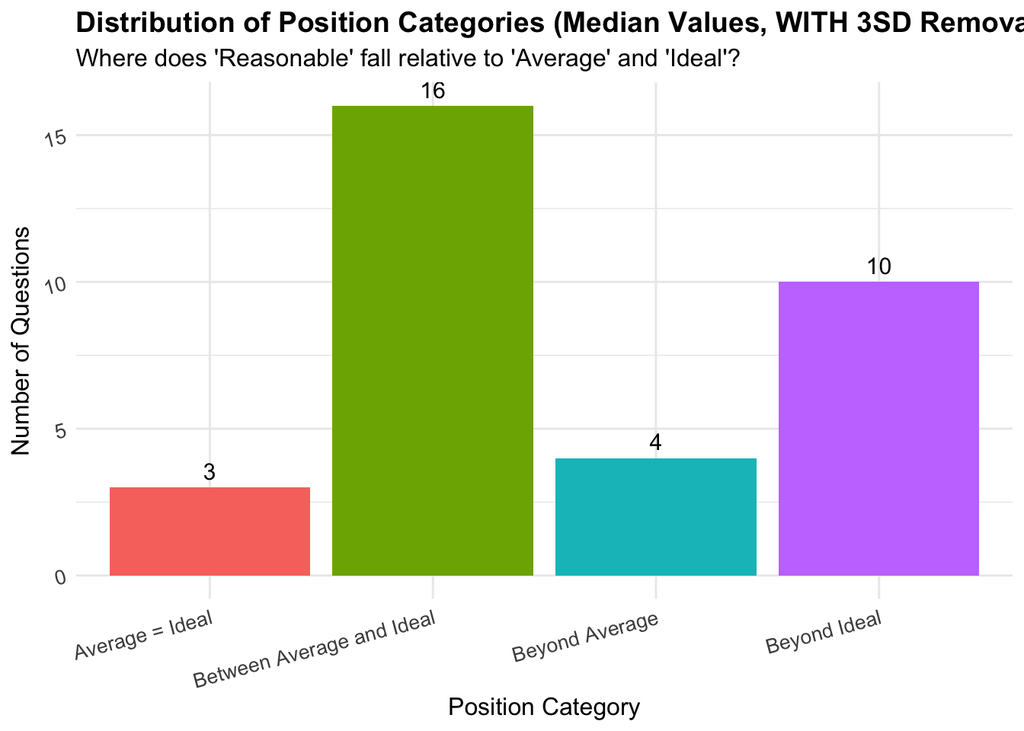

```r
# Create distribution plot
position_distribution_plot_median_3sd <- ggplot(position_summary_median_3sd, aes(x = Position, y = Count, fill = Position)) +
  geom_bar(stat = "identity") +
  geom_text(aes(label = paste0(Count)), vjust = -0.5, size = 4) +
  labs(title = "Distribution of Position Categories (Median Values, WITH 3SD Removal)",
       subtitle = "Where does 'Reasonable' fall relative to 'Average' and 'Ideal'?",
       x = "Position Category", y = "Number of Questions") +
  theme_minimal() + theme(plot.title = element_text(size = 14, face = "bold"), plot.subtitle = element_text(size = 12), axis.title = element_text(size = 12), axis.text = element_text(size = 10, angle = 15, hjust = 1), legend.position = "none")
print(position_distribution_plot_median_3sd)
```

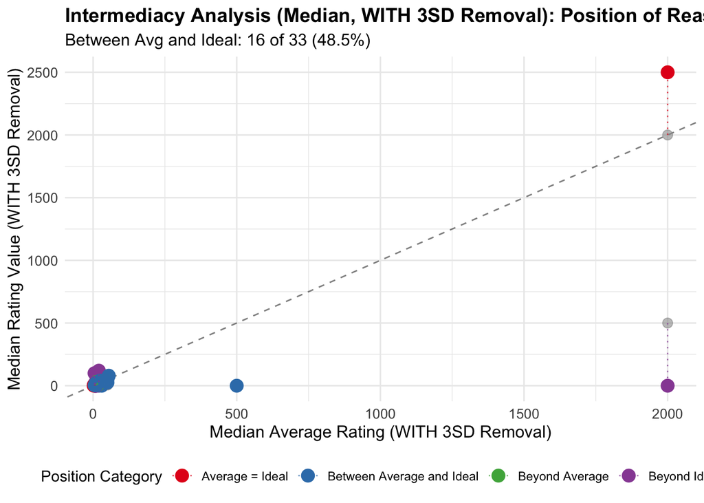

```r
ggsave("position_distribution_median_with_3sd_removed.png", position_distribution_plot_median_3sd, width = 10, height = 7, dpi = 300)

# Create scatterplot
plot_data_intermediacy_3sd <- question_position_summary_median_3sd %>% filter(!is.na(Average_Value) & !is.na(Ideal_Value) & !is.na(Reasonable_Value))
intermediacy_plot_median_3sd <- ggplot(plot_data_intermediacy_3sd, aes(x = Average_Value, y = Ideal_Value)) +
  geom_abline(intercept = 0, slope = 1, linetype = "dashed", alpha = 0.5) +
  geom_point(color = "gray60", size = 3, alpha = 0.6) +
  geom_point(aes(x = Average_Value, y = Reasonable_Value, color = Position), size = 4) +
  geom_segment(aes(x = Average_Value, xend = Average_Value, y = Ideal_Value, yend = Reasonable_Value, color = Position), linetype = "dotted", size = 0.5, alpha = 0.7) +
  scale_color_brewer(palette = "Set1") +
  labs(title = "Intermediacy Analysis (Median, WITH 3SD Removal): Position of Reasonable",
       subtitle = paste0("Between Avg and Ideal: ", count_both_sides_median_3sd, " of ", valid_questions_both_3sd, " (", scales::percent(count_both_sides_median_3sd/valid_questions_both_3sd, accuracy=0.1), ")"),
       x = "Median Average Rating (WITH 3SD Removal)", y = "Median Rating Value (WITH 3SD Removal)", color = "Position Category") +
  theme_minimal() + theme(plot.title = element_text(size = 14, face = "bold"), plot.subtitle = element_text(size = 12), axis.title = element_text(size = 12), axis.text = element_text(size = 10), legend.position = "bottom")
print(intermediacy_plot_median_3sd)
```

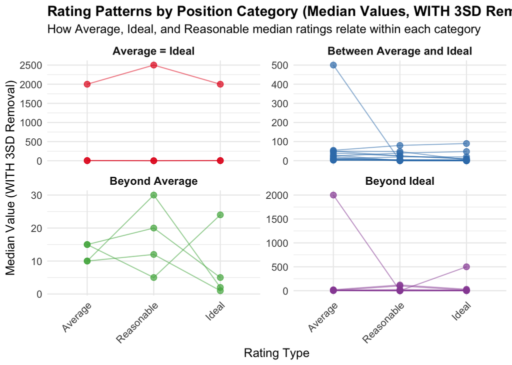

```r
ggsave("intermediacy_analysis_median_with_3sd_removed.png", intermediacy_plot_median_3sd, width = 10, height = 8, dpi = 300)

# Create rating patterns plot
ratings_long_median_3sd <- question_position_summary_median_3sd %>%
  select(Question, Average_Value, Ideal_Value, Reasonable_Value, Position) %>%
  pivot_longer(cols = c(Average_Value, Ideal_Value, Reasonable_Value), names_to = "Rating_Type", values_to = "Value") %>%
  mutate(Rating_Type = factor(gsub("_Value", "", Rating_Type), levels = c("Average", "Reasonable", "Ideal"))) %>%
  filter(!is.na(Value))
rating_patterns_plot_median_3sd <- ggplot(ratings_long_median_3sd, aes(x = Rating_Type, y = Value, group = Question, color = Position)) +
  geom_line(alpha = 0.5) + geom_point(size = 2.5, alpha=0.7) + facet_wrap(~ Position, scales = "free_y") +
  scale_color_brewer(palette = "Set1") +
  labs(title = "Rating Patterns by Position Category (Median Values, WITH 3SD Removal)",
       subtitle = "How Average, Ideal, and Reasonable median ratings relate within each category",
       x = "Rating Type", y = "Median Value (WITH 3SD Removal)") +
  theme_minimal() + theme(plot.title = element_text(size = 14, face = "bold"), plot.subtitle = element_text(size = 12), axis.title = element_text(size = 12), axis.text.x = element_text(size = 10, angle = 45, hjust = 1), axis.text.y = element_text(size = 10), strip.text = element_text(size=11, face="bold"), legend.position = "none")
print(rating_patterns_plot_median_3sd)
```

```r
ggsave("rating_patterns_by_position_median_with_3sd_removed.png", rating_patterns_plot_median_3sd, width = 12, height = 8, dpi = 300)

# Store results
analysis_4_results_3sd <- list(
  ideal_side = list(vector=ideal_side_vector_median_3sd, count=count_ideal_side_median_3sd, valid_n=valid_questions_ideal_3sd, summary=ideal_side_summary_median_3sd),
  average_side = list(vector=average_side_vector_median_3sd, count=count_average_side_median_3sd, valid_n=valid_questions_avg_3sd, summary=average_side_summary_median_3sd),
  both_sides = list(vector=both_sides_vector_median_3sd, count=count_both_sides_median_3sd, valid_n=valid_questions_both_3sd, summary=both_sides_summary_median_3sd),
  question_position = question_position_summary_median_3sd,
  position_summary = position_summary_median_3sd
)
```